# Analyses of GSE121575

Proximity RNA Labeling by APEX-Seq Reveals the Organization of Translation Initiation Complexes and Repressive RNA Granules

Alexandre Kaizeler[^1] - alexandreafonso@gimm.pt<

22 July 2026

# Introduction

In this document, I present all analyses pertaining to the dataset **GSE121575**  
([NCBI GEO Link](https://www.ncbi.nlm.nih.gov/geo/query/acc.cgi?acc=GSE121575)),  
originally published by **A. Padrón, 2019**.

## Methodology

```r
# These are all the libraries I used throughout the analysis. Not all of them will be required on this guidebook
library(Rsubread)
library(limma)
library(edgeR)
library(DESeq2)
library(magrittr)
library(ggrepel)
library(tidyverse)
library(vsn)
library(ggplot2)
library(NMF)
library(biomaRt)
library(ggpubr)
library(factoextra)
library(ggfortify)
library(plotly)
library(reshape2)
library(fgsea)
library(msigdbr)
library(data.table)
library(colorspace)


set.seed(1906)
```

## First Steps

```r
#This section here is to load up the genelenght file I will be using throughout the analyses.
genelength <- read.csv("~/Projects/StressGranules/SG_Transcriptome/RP_Data_2021/TrimmedSamples/alignment_STAR/TranscriptLenght.txt", header=T)

genelength <- subset(genelength, Ensembl.Canonical==1)
genelength <- subset(genelength, Gene.name!="")

genelength <- genelength %>%
  group_by(Gene.name) %>%
  slice(which.max(Transcript.length..including.UTRs.and.CDS.)) %>%
  ungroup()

genelength <- genelength[,-c(2,3)]
colnames(genelength) <- c("Length", "Gene")




# Get the table of read counts by indicating the path to the file. This file is what we obtained from the running featureCounts.

sg.read.counts <- read.table("~/Projects/StressGranules/SG_Transcriptome/RP_Data_2019.1/TrimmedSamples/alignment_STAR/featureCounts_results.txt", header=TRUE)

# Afterwards, I discard the columns which don't have read counts. These columns are only informations about the gene.
sg.read.counts <- sg.read.counts[,-c(2:6)]

#Loading up our biomart file, obtained from Ensembl, where we have the equivalence between Ensembl IDs and HGNC names
biomart <- fread("~/biomart.txt")[,-1]


colnames(sg.read.counts)[1] <- "ensembl_gene_id_version"
colnames(biomart) <- c("ensembl_gene_id_version", "hgnc_symbol")

eltable <- merge(sg.read.counts,biomart,by = "ensembl_gene_id_version", all= TRUE) #this creates a table with both ensemble ids and HGNC codes.

eltable <- subset(eltable, hgnc_symbol!="") #this removes reads that dont have a corresponding hgnc symbol.

eltable$ensembl_gene_id_version <- NULL

read.counts <- eltable %>% # If two gene ids resulted in the same gene name, this will sum up their counts
  group_by(hgnc_symbol) %>%
  summarise(across(everything(), sum, na.rm = TRUE))
read.counts <- as.data.frame(read.counts)

row.names(read.counts) <- read.counts$hgnc_symbol #changes rownames into hgnc symbols
read.counts$hgnc_symbol <- NULL #We no longer need this column, as we have the rownames.
```

## Extra Quality Control

Let’s check for sample complexity. It is possible that one or more samples have different complexity. In specific, I am going to check if enough reads have been obtained from every sample. If not, we should have a great bias to housekeeping genes. Another way to put it, is to say that even with all reads, we won’t obtain a great deal of different genes.

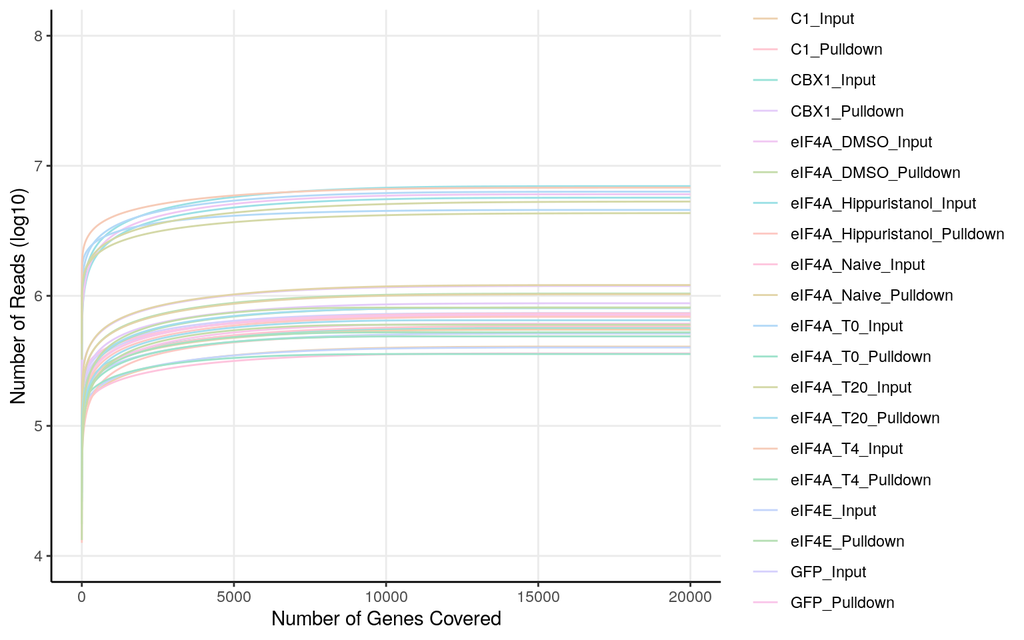

```r
# Define color palette
custom_palette <- qualitative_hcl(20, palette = "Pastel")
custom_palette <- sample(custom_palette, 20)

# Use SampleColouring from metadata
SampleColouring <- c("CBX1_Input", "CBX1_Input", "C1_Input", "C1_Input", "GFP_Input", "GFP_Input", "eIF4E_Input", "eIF4E_Input", "eIF4A_Naive_Input", "eIF4A_Naive_Input", "eIF4A_Hippuristanol_Input", "eIF4A_Hippuristanol_Input", "eIF4A_DMSO_Input", "eIF4A_T0_Input", "eIF4A_T0_Input", "eIF4A_T4_Input", "eIF4A_T20_Input", "eIF4A_T20_Input", "CBX1_Pulldown", "CBX1_Pulldown", "C1_Pulldown", "C1_Pulldown", "GFP_Pulldown", "GFP_Pulldown", "eIF4E_Pulldown", "eIF4E_Pulldown", "eIF4A_Naive_Pulldown", "eIF4A_Naive_Pulldown", "eIF4A_Hippuristanol_Pulldown", "eIF4A_Hippuristanol_Pulldown", "eIF4A_T0_Pulldown", "eIF4A_T0_Pulldown", "eIF4A_T4_Pulldown", "eIF4A_T20_Pulldown", "eIF4A_T20_Pulldown", "eIF4A_DMSO_Pulldown", "eIF4A_DMSO_Pulldown")

# Build cumulative counts
final <- sapply(1:ncol(read.counts), function(i) {
  sort_vals <- read.counts[order(read.counts[, i], decreasing = TRUE), i]
  cumsum(sort_vals)
})
final <- as.data.frame(final)
colnames(final) <- colnames(read.counts)

# Melt and add gene position + sample info
finalmelt <- reshape2::melt(final, variable.name = "Sample")
finalmelt$genes <- rep(1:nrow(final), times = ncol(final))
finalmelt$SampleColouring <- rep(SampleColouring, each = nrow(final))

# Plot cumulative read coverage
ggplot(data = finalmelt, aes(x = genes, y = log10(value), group = Sample, color = SampleColouring)) +
  geom_line() +
  scale_color_manual(values = custom_palette, name = "Cell Line") +
  theme_bw() +
  xlab("Number of Genes Covered") +
  ylab("Number of Reads (log10)") +
  xlim(0, 20000) +
  ylim(4, 8) +
  theme(
    axis.line = element_line(colour = "black"),
    panel.grid.minor = element_blank(),
    panel.border = element_blank(),
    panel.background = element_blank()
  )
```

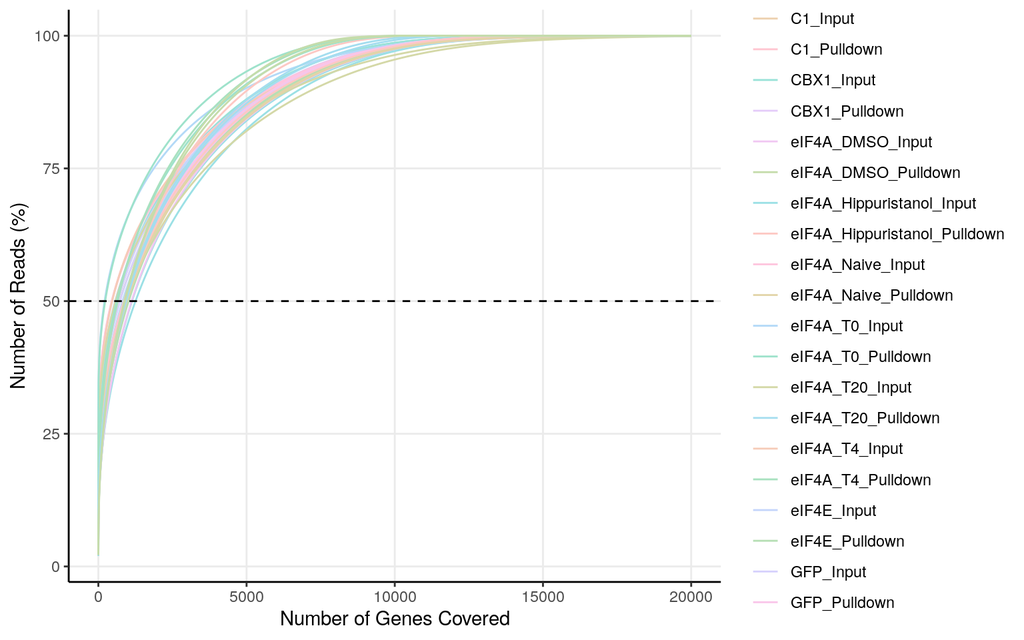

```r
# Create percentage-based plot
orderfinal <- subset(finalmelt, genes == max(finalmelt$genes))
trial <- merge(orderfinal[, c("Sample", "value")], finalmelt, by = "Sample", suffixes = c(".total", ".current"))
trial$percent <- (trial$value.current / trial$value.total) * 100
trial$SampleColouring <- rep(SampleColouring, each = nrow(final))

ggplot(data = trial, aes(x = genes, y = percent, group = Sample, color = SampleColouring)) +
  geom_line() +
  geom_hline(yintercept = 50, linetype = "dashed") +
  scale_color_manual(values = custom_palette, name = "Cell Line") +
  xlab("Number of Genes Covered") +
  ylab("Number of Reads (%)") +
  xlim(0, 20000) +
  theme_bw() +
  theme(
    axis.line = element_line(colour = "black"),
    panel.grid.minor = element_blank(),
    panel.border = element_blank(),
    panel.background = element_blank()
  )
```

# Differential Expression Analysis

## Filtration

### *Before Filtration*

Let us begin with the filtration. Personally, I find that its easier to do visually. I am aware that my filtration is more violent than most. Usually, from RNA-Seq experiments, we commonly obtain bi-modal distributions, with the first mode corresponding to lowly expressed genes. I remove these by cutting just before the second mode. For simplicity, I start by filtering all samples together, irrespective of sample type.

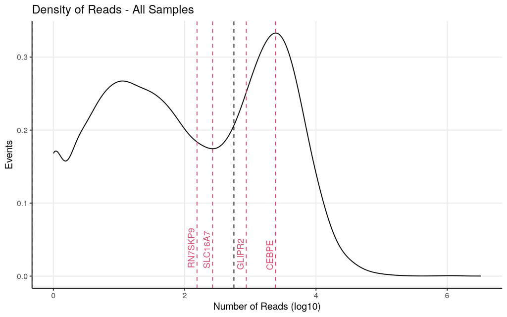

```r
alternew <- log10(rowSums(read.counts))
alternew <- as.data.frame(alternew)

genes_of_interest <- c("CEBPE", "GLIPR2", "RN7SKP9", "SLC16A7", "EEF1A2", "TSIX")

gene_lines <- data.frame(
  Gene  = genes_of_interest,
  value = alternew[genes_of_interest, "alternew"]
)

ggplot(alternew, aes(x = alternew)) +
  geom_density() +
  theme_bw() +
  geom_vline(xintercept = 2.75, linetype = "dashed") +
  geom_vline(data = gene_lines, aes(xintercept = value), linetype = "dashed", color = "#DB5375") +
  geom_text(data = gene_lines, aes(x = value, y = 0, label = Gene),
            angle = 90, hjust = -0.2, vjust = -0.4, size = 3.5, color = "#DB5375") +
  ylab("Events") + xlab("Number of Reads (log10)") +
  theme(axis.line = element_line(colour = "black"),
        panel.grid.minor = element_blank(),
        panel.border = element_blank(),
        panel.background = element_blank()) +
  ggtitle("Density of Reads - All Samples")
```

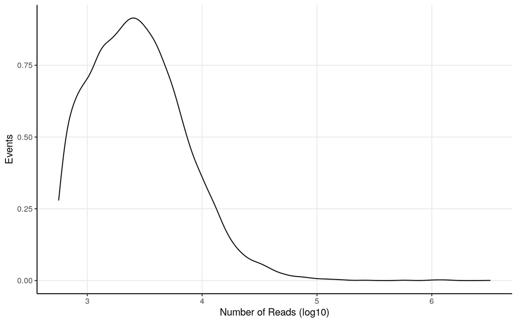

```r
filterednew <- subset(read.counts, alternew>2.75)

#after cutting, its a good idea to visualize again
falternew <- log10(rowSums(filterednew))
falternew <- as.data.frame(falternew)
ggplot(falternew, aes(x=falternew)) + geom_density() + theme_bw() + ylab("Events") + xlab("Number of Reads (log10)") +
  theme(axis.line = element_line(colour = "black"),
        panel.grid.minor = element_blank(),
        panel.border = element_blank(),
        panel.background = element_blank())
```

```r
#lets save the genes which we maintain
impgenes <- c(row.names(falternew))

#Now we need to select only the rows which have those genes.
finaltable <- read.counts[row.names(read.counts)%in%impgenes,]

colnames(finaltable) <- gsub('Aligned.sortedByCoord.out.bam', '', colnames(finaltable))
```

By seeing the shape of the graph, we can see where we should cut. We have a **binomial distribution** (low reads and noise vs actual biological meaningful reads). The ideal place to cut them is right before the wedge.

## Matrices

Good! Now we can proceed by designing our matrices.

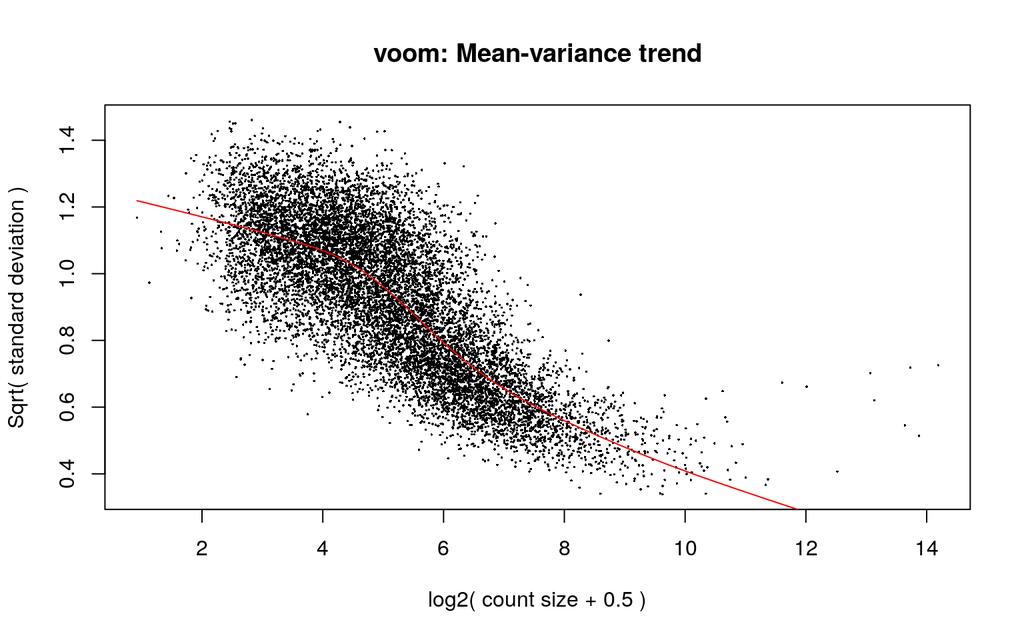

```r
#Let us prepare metadata to add to our samples
#Generic full sample name
forall <- c("CBX1_Input", "CBX1_Input", "C1_Input", "C1_Input", "GFP_Input", "GFP_Input", "eIF4E_Input", "eIF4E_Input", "eIF4A_Naive_Input", "eIF4A_Naive_Input", "eIF4A_Hippuristanol_Input", "eIF4A_Hippuristanol_Input", "eIF4A_DMSO_Input", "eIF4A_T0_Input", "eIF4A_T0_Input", "eIF4A_T4_Input", "eIF4A_T20_Input", "eIF4A_T20_Input", "CBX1_Pulldown", "CBX1_Pulldown", "C1_Pulldown", "C1_Pulldown", "GFP_Pulldown", "GFP_Pulldown", "eIF4E_Pulldown", "eIF4E_Pulldown", "eIF4A_Naive_Pulldown", "eIF4A_Naive_Pulldown", "eIF4A_Hippuristanol_Pulldown", "eIF4A_Hippuristanol_Pulldown", "eIF4A_T0_Pulldown", "eIF4A_T0_Pulldown", "eIF4A_T4_Pulldown", "eIF4A_T20_Pulldown", "eIF4A_T20_Pulldown", "eIF4A_DMSO_Pulldown", "eIF4A_DMSO_Pulldown")
#Input vs Pulldown
fortype <- c("Input", "Input", "Input", "Input", "Input", "Input", "Input", "Input", "Input", "Input", "Input", "Input", "Input", "Input", "Input", "Input", "Input", "Input", "Pulldown", "Pulldown", "Pulldown", "Pulldown", "Pulldown", "Pulldown", "Pulldown", "Pulldown", "Pulldown", "Pulldown", "Pulldown", "Pulldown", "Pulldown", "Pulldown", "Pulldown", "Pulldown", "Pulldown", "Pulldown", "Pulldown")
#Each of these samples has one of these proteins linked to apex
forgenome <- c("CBX1", "CBX1", "C1", "C1", "GFP", "GFP", "eIF4E", "eIF4E", "eIF4A", "eIF4A", "eIF4A", "eIF4A", "eIF4A", "eIF4A", "eIF4A", "eIF4A", "eIF4A", "eIF4A", "CBX1", "CBX1", "C1", "C1", "GFP", "GFP", "eIF4E", "eIF4E", "eIF4A", "eIF4A", "eIF4A", "eIF4A", "eIF4A", "eIF4A", "eIF4A", "eIF4A", "eIF4A", "eIF4A", "eIF4A")
#Stress State. I assumed that "Naive" were equal to T0 samples
forstress <- c("Control", "Control", "Control", "Control", "Control", "Control", "Control", "Control", "Control", "Control", "Hippuristanol", "Hippuristanol", "DMSO", "Control", "Control", "T4", "T20", "T20", "Control", "Control", "Control", "Control", "Control", "Control", "Control", "Control", "Control", "Control", "Hippuristanol", "Hippuristanol", "Control", "Control", "T4", "T20", "T20", "DMSO", "DMSO")
#Target. What in theory is being captured.
fortarget <- c("NonSpe", "NonSpe", "NonSpe", "NonSpe", "NonSpe", "NonSpe", "NonSpe", "NonSpe", "NonSpe", "NonSpe", "NonSpe", "NonSpe", "NonSpe", "NonSpe", "NonSpe", "NonSpe", "NonSpe", "NonSpe", "CBX1", "CBX1", "C1", "C1", "GFP", "GFP", "eIF4E", "eIF4E", "eIF4A", "eIF4A", "SG", "SG", "eIF4A", "eIF4A", "SG", "SG", "SG", "eIF4A", "eIF4A")

#To be able to use Voom, we must first convert our read count table into a special DGE object.

#This one has all samples
D0 <- DGEList(finaltable)

#Then we calculate the normalization factors for these new generated data frames
#Bear in mind this step calculates the normalization factors, but does not normalize itself.
D0 <- calcNormFactors(D0)


#Now we do the matrixes
mm <- model.matrix(~0+forall)

#Now we do the matrixes
mm.complex <- model.matrix(~0+fortype+forgenome+forstress+fortarget)


#and now we normalize. This step also turns our counts into log2-counts per million.
y <- voom(D0, mm, plot = T)
```

[output not shown]

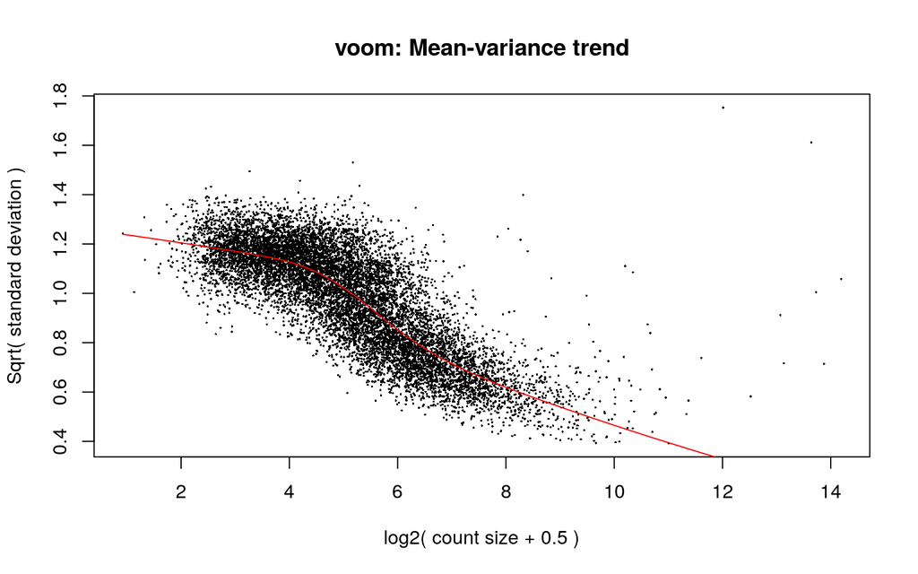

```r
y.complex <- voom(D0, mm.complex, plot = T)
```

## Normalisation

For normalisation I convert the read counts into log2CPMs. Its a good way to visualise how the reads are.

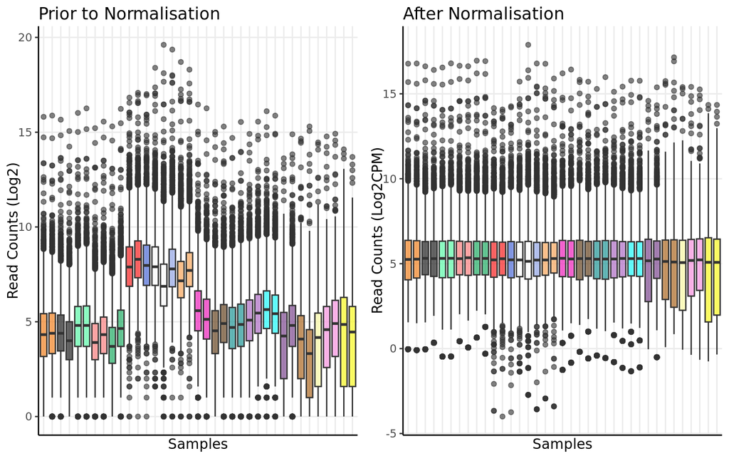

```r
dfforboxy <- finaltable


orderforplots <- forall
colouring <- data.frame(Sample=colnames(dfforboxy), Types=orderforplots)
dfforboxy <- reshape2::melt(dfforboxy)
colnames(dfforboxy) <- c("Sample", "Expression")
dfforboxy <- merge(dfforboxy, colouring, by="Sample")
dfforboxy$Sample <- factor(dfforboxy$Sample, levels = unique(colouring$Sample))
prenorm <- ggplot(dfforboxy, aes(x=Sample, y=(log2(Expression+1)), fill=Types)) + geom_boxplot(alpha=0.6) + theme_bw() + ylab("Read Counts (Log2)") + xlab("Samples") + scale_fill_manual(name = "Sample Type", values = c("#000000", "#522A00", "#F57200", "#F202B6", "#3457D5", "#FFFF00", "#FE0000", "#6C3082", "#00A550", "cyan" ,"#FFFFFF", "#A35400", "#FF9D47", "#FE86E0", "#889DE7", "#FFFF99", "#FF7070", "#A75BC2", "#47FFA0", "cyan4")) +
  theme(axis.line = element_line(colour = "black"),
        panel.grid.minor = element_blank(),
        panel.border = element_blank(),
        panel.background = element_blank(),
        axis.text.x=element_blank(),
        axis.ticks.x=element_blank(),
        legend.position = "None") + ggtitle("Prior to Normalisation") + theme(text=element_text(family = "Quicksand"))

#Using the Standard Matrix

dfforboxy <- y$E
dfforboxy <- reshape2::melt(dfforboxy)
dfforboxy <- dfforboxy[,-1]
colnames(dfforboxy) <- c("Sample", "Expression")
dfforboxy <- merge(dfforboxy, colouring, by="Sample")
postnorm <- ggplot(dfforboxy, aes(x=Sample, y=Expression, fill=Types)) + geom_boxplot(alpha=0.6) + theme_bw() + ylab("Read Counts (Log2CPM)") + xlab("Samples") + scale_fill_manual(name = "Sample Type", values = c("#000000", "#522A00", "#F57200", "#F202B6", "#3457D5", "#FFFF00", "#FE0000", "#6C3082", "#00A550", "cyan" ,"#FFFFFF", "#A35400", "#FF9D47", "#FE86E0", "#889DE7", "#FFFF99", "#FF7070", "#A75BC2", "#47FFA0", "cyan4")) +
  theme(axis.line = element_line(colour = "black"),
        panel.grid.minor = element_blank(),
        panel.border = element_blank(),
        panel.background = element_blank(),
        axis.text.x=element_blank(),
        axis.ticks.x=element_blank(),
        legend.position = "None") + ggtitle("After Normalisation")+ theme(text=element_text(family = "Quicksand"))

ggarrange(prenorm, postnorm, nrow=1)
```

As expected due to the big differences in complexity and read depth, there are still some issues with the normalisation.

## PCA

I like to start with a Principal Component Analysis (PCA), which helps to identify what drives the largest variation in the data. This time, I also plotted a simple correlation heatmap between samples.

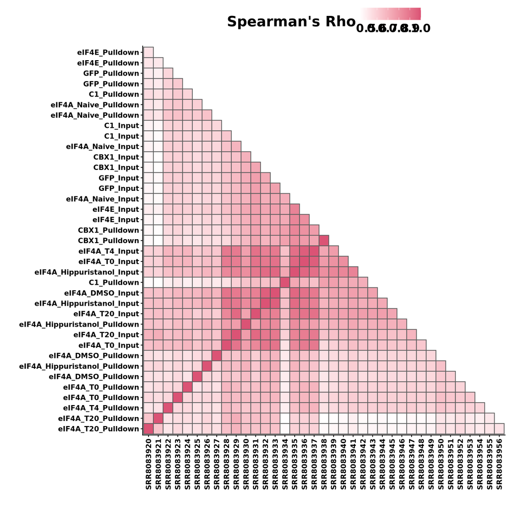

```r
# Define color palette
custom_palette <- qualitative_hcl(7, palette = "Pastel")
custom_palette <- sample(custom_palette, 7)


library(reshape2)
library(dplyr)
library(ggplot2)
cormat <- cor(y$E, method = "spearman")

# Euclidean clustering on the correlation matrix itself — each sample's
# correlation profile vs. every other sample as coordinates — not on
# raw expression (dist(t(y$E))) or on 1-cormat (correlation-distance)
hc <- hclust(dist(cormat))
sample_order <- colnames(cormat)[hc$order]

cormat_melt <- reshape2::melt(cormat)
N <- length(sample_order)

heat_df <- cormat_melt %>%
  mutate(Var1 = factor(Var1, levels = sample_order),
         Var2 = factor(Var2, levels = sample_order)) %>%
  arrange(Var1) %>%
  filter(as.numeric(Var1) + as.numeric(Var2) <= N + 1)   # right angle at bottom-left

# Labels must be reordered to match the clustering order — SampleColouring
# is aligned to the original column order of y$E, not to sample_order,
# so it needs re-indexing or the wrong group names end up on the axis
sample_labels <- SampleColouring[match(sample_order, colnames(y$E))]

(p_corr <- ggplot(heat_df, aes(x = Var1, y = Var2, fill = value)) +
  geom_tile(color = "#5e5e5e", size = 0.5) +
  scale_fill_gradient(low = "white", high = "#DB5375") +
  labs(fill = "Spearman's Rho") +
  theme_classic() +
  theme(
    axis.text.x = element_text(angle = 90, hjust = 1, vjust = 0.5, size = 10, face = "bold"),
    axis.text.y = element_text(angle = 0, hjust = 1, size = 10, face = "bold"),
    plot.title = element_text(hjust = 0.5),
    text = element_text(size = 20, family = "Arial MS", face = "bold"),
    legend.position = "top"
  ) +
  ylab("") + xlab("") +
  scale_y_discrete(labels = sample_labels) +
  scale_x_discrete(labels = colnames(y$E)))
```

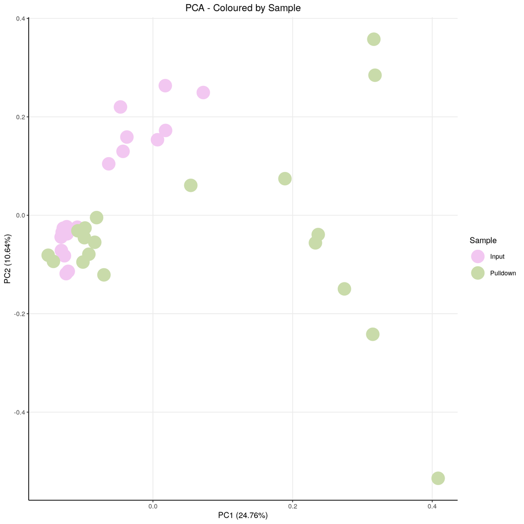

```r
#This prepares my data for the PCA
dfforpca <- y$E
dfforpca <- t(dfforpca)
dfforpca <- as.data.frame(dfforpca) # needs to be a data.frame
dfforpca <- apply(dfforpca, 2, as.numeric) # Ensure numeric
dfforpca <- as.data.frame(dfforpca) # still needs to be a data.frame

# Add metadata, which we will then use to plot
dfforpca$Sample <- fortype
dfforpca$Stress <- forstress
dfforpca$Genome <- forgenome
dfforpca$Target <- fortarget

# PCA computation itself. I do one PCA for each variable I want to see.
pca_res <- prcomp(dfforpca[, 1:(ncol(dfforpca)-4)], scale = FALSE)

p_Sample <- autoplot(pca_res, data = dfforpca, x = 1, y = 2, colour = "Sample", size = 8) +
  theme_bw() +
  scale_colour_manual(name = "Sample", values = custom_palette) +
  ggtitle("PCA - Coloured by Sample") +
  theme(plot.title = element_text(hjust = 0.5),
        axis.line = element_line(colour = "black"),
        panel.grid.minor = element_blank(),
        panel.border = element_blank(),
        panel.background = element_blank())
p_Stress <- autoplot(pca_res, data = dfforpca, x = 1, y = 2, colour = "Stress", size = 8) +
  theme_bw() +
  scale_colour_manual(name = "Stress", values = custom_palette) +
  ggtitle("PCA - Coloured by Stress") +
  theme(plot.title = element_text(hjust = 0.5),
        axis.line = element_line(colour = "black"),
        panel.grid.minor = element_blank(),
        panel.border = element_blank(),
        panel.background = element_blank())

p_Genome <- autoplot(pca_res, data = dfforpca, x = 1, y = 2, colour = "Genome", size = 8) +
  theme_bw() +
  scale_colour_manual(name = "Genome", values = custom_palette) +
  ggtitle("PCA - Coloured by Genome") +
  theme(plot.title = element_text(hjust = 0.5),
        axis.line = element_line(colour = "black"),
        panel.grid.minor = element_blank(),
        panel.border = element_blank(),
        panel.background = element_blank())

p_Target <- autoplot(pca_res, data = dfforpca, x = 1, y = 2, colour = "Target", size = 8) +
  theme_bw() +
  scale_colour_manual(name = "Target", values = custom_palette) +
  ggtitle("PCA - Coloured by Target") +
  theme(plot.title = element_text(hjust = 0.5),
        axis.line = element_line(colour = "black"),
        panel.grid.minor = element_blank(),
        panel.border = element_blank(),
        panel.background = element_blank())

p_Sample
```

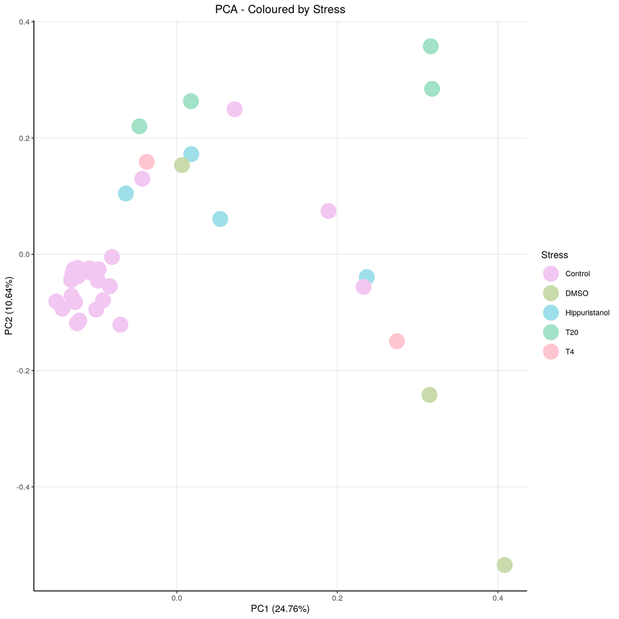

```r
p_Stress
```

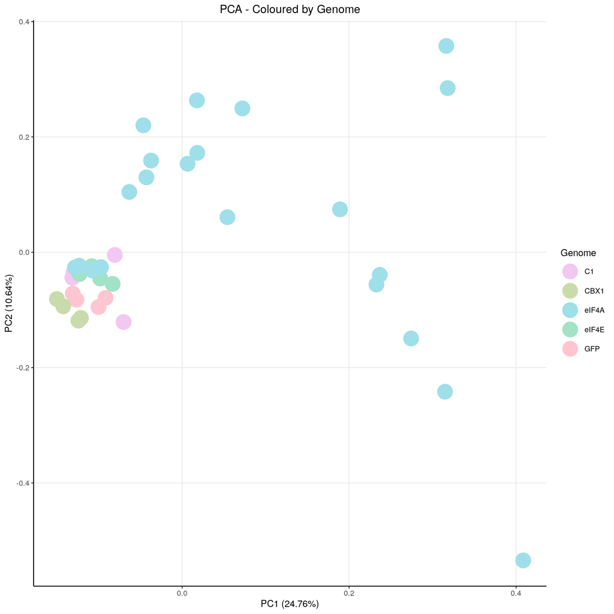

```r
p_Genome
```

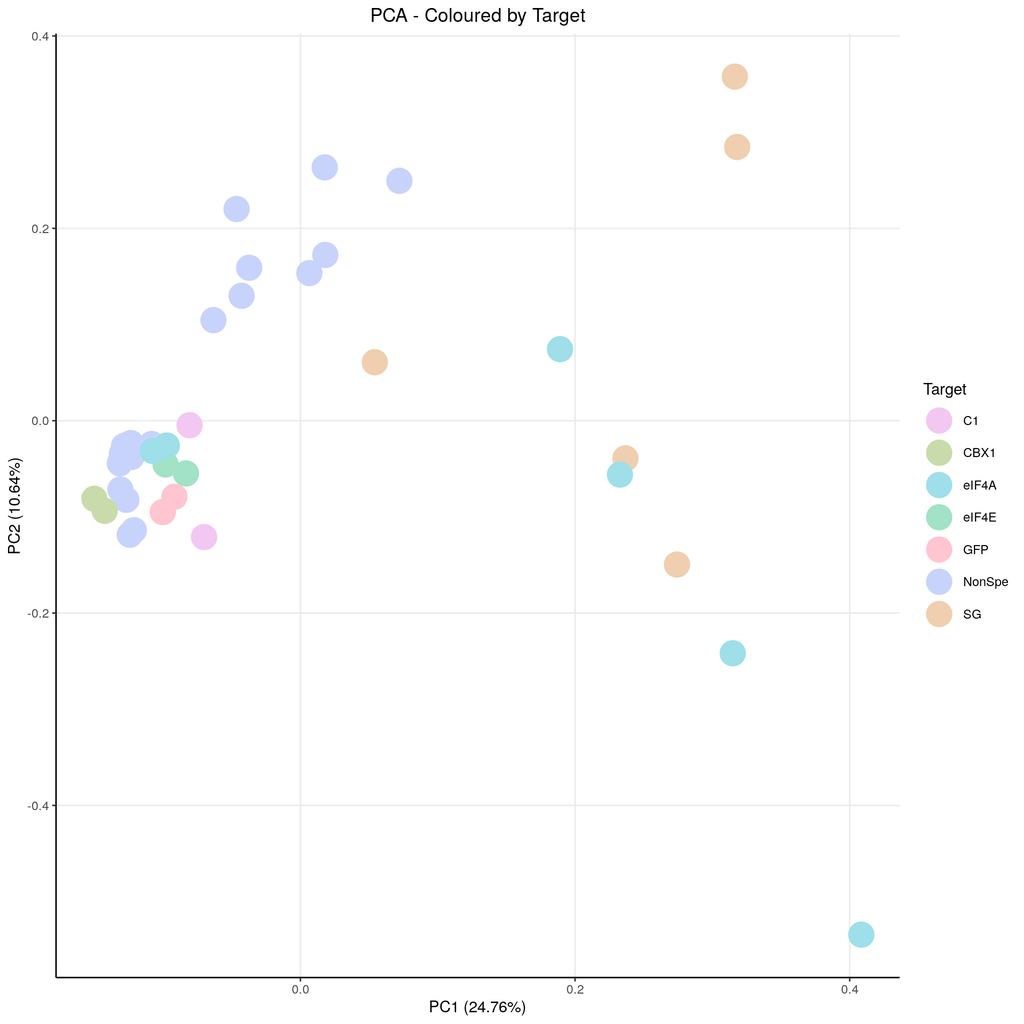

```r
p_Target
```

```r
#in case you want to see most important genes for PCA yourself
contribs1 <- pca_res$rotation[,1]
contribs2 <- pca_res$rotation[,2]

#These are the biggest contributors to the PCA1 (right side)
(pos1genes <- sort(contribs1, decreasing=T)[1:10])
```

```
##    KLHDC7B     RNU4-2    RAPGEF3     CACFD1      GDF15      CNTN3      MXRA8
## 0.02507575 0.01975422 0.01941989 0.01924867 0.01911074 0.01888432 0.01872780
##       MPND     MAPK11     PLPPR3
## 0.01808294 0.01805049 0.01766026
```

```r
#These are the biggest contributors to the PCA1 (left side)
(neg1genes <- sort(contribs1, decreasing=F)[1:10])
```

```
##      ZBTB41    MTND2P28       RESF1     SLC30A7       ACSL4      STEAP2
## -0.03344772 -0.03172520 -0.03097650 -0.03009235 -0.02960157 -0.02939337
##      FNBP1L     OTULINL        MCM9      ZNF155
## -0.02932647 -0.02861258 -0.02819378 -0.02782489
```

```r
#These are the biggest contributors to the PCA2 (up side)
(pos2genes <- sort(contribs2, decreasing=T)[1:10])
```

```
##      NOXA1   RPAP3-DT       APC2     MIR612     MAMDC4      CHAC1      SYTL1
## 0.03780555 0.03651713 0.03644859 0.03577113 0.03487181 0.03477532 0.03441483
##    DENND6B      SNX32      ITGB4
## 0.03426716 0.03425680 0.03407241
```

```r
#These are the biggest contributors to the PCA2 (down side)
(neg2genes <- sort(contribs2, decreasing=F)[1:10])
```

```
##     MT-RNR1     MT-RNR2      MT-TL1    MTND4P12     MT-ATP6     MT-ATP8
## -0.07227080 -0.05874876 -0.04768462 -0.04421992 -0.04310211 -0.03892955
##       CNTN3      MT-ND2       MT-TE      MT-ND6
## -0.03882221 -0.03819106 -0.03681166 -0.03665145
```

There are some samples which aren’t as similar as expected. Nevertheless, I opted to continue. This heatmap was also useful to decide what comparisons to do. Also, as T20 pulldowns are closer to each other than Hipu, for simple comparisons I focused on these.

```r
eif4a_idx <- which(forgenome == "eIF4A" & fortype == "Pulldown")
eif4a_expr <- y$E[, eif4a_idx]
eif4a_condition <- forall[eif4a_idx]   # full label: keeps Naive and T0 distinct
colnames(eif4a_expr) <- eif4a_condition

conditions_of_interest <- c("eIF4A_Naive_Pulldown", "eIF4A_Hippuristanol_Pulldown",
                             "eIF4A_T20_Pulldown", "eIF4A_T0_Pulldown")

plot_list <- lapply(conditions_of_interest, function(cond) {
  idx <- which(eif4a_condition == cond)
  df <- data.frame(Rep1 = eif4a_expr[, idx[1]], Rep2 = eif4a_expr[, idx[2]])
  rho <- cor(df$Rep1, df$Rep2, method = "spearman")

  ggplot(df, aes(x = Rep1, y = Rep2)) +
    geom_point(fill = "#DDDDDD", alpha = 0.3, size = 5, shape = 21, colour = 'black') +
    geom_density2d(color = "#800020", size = 1.2) +
    geom_abline(slope = 1, intercept = 0, linetype = "dashed", color = "grey40") +
    theme_bw() +
    ylab(paste0(colnames(y$E)[idx[2]], "\n")) + xlab(colnames(y$E)[idx[1]]) +
    ggtitle(cond) +
    theme(axis.line = element_line(colour = "black"),
          panel.grid.minor = element_blank(),
          panel.border = element_blank(),
          panel.background = element_blank()) +
    theme(plot.title = element_text(hjust = 0.5)) +
    theme(text = element_text(size = 16, family = "Arial MS")) +
    stat_cor(method = "spearman", cor.coef.name = "rho", size = 6) +
    theme(panel.grid.major = element_blank(), panel.grid.minor = element_blank())
})

p_corr <- ggpubr::ggarrange(plotlist = plot_list, ncol = 2, nrow = 2)
```

[output not shown]

[output not shown]

```r
png("~/Projects/StressGranules/SGPAPER/Images/PNG/Sup_PadronA.png", width = 14, height=12, units = "in", res=300)
p_corr
dev.off()
```

## Linear Models

Now we must perform linear model fitting.

```r
fitted <- lmFit(y, mm)
fitted_complex <- lmFit(y.complex, mm.complex)
```

```
## Coefficients not estimable: fortargetNonSpe
```

```r
head(coef(fitted))
```

```
##          forallC1_Input forallC1_Pulldown forallCBX1_Input forallCBX1_Pulldown
## 7SK           14.478055         12.294381       14.2342988           12.884229
## A1BG           3.611863          4.546119        0.7276153            2.734190
## A1BG-AS1       2.818722          5.190496        2.6827380            3.950353
## AAAS           6.404306          5.324034        6.9995050            6.179876
## AACS           5.724108          4.697057        4.8413569            5.064754
## AADAT          2.545324          1.476375        2.7423724            2.419113
##          foralleIF4A_DMSO_Input foralleIF4A_DMSO_Pulldown
## 7SK                   13.182500                11.5681811
## A1BG                   3.771707                 0.6100223
## A1BG-AS1               4.144750                -0.5509417
## AAAS                   6.728698                 6.5549060
## AACS                   6.243271                 6.6244257
## AADAT                  2.942508                 1.3147344
##          foralleIF4A_Hippuristanol_Input foralleIF4A_Hippuristanol_Pulldown
## 7SK                            13.457487                          11.913910
## A1BG                            3.433935                           2.945976
## A1BG-AS1                        4.099020                           2.492607
## AAAS                            6.654057                           6.260340
## AACS                            6.170743                           5.206666
## AADAT                           3.206637                           3.554509
##          foralleIF4A_Naive_Input foralleIF4A_Naive_Pulldown
## 7SK                    14.743916                  11.916927
## A1BG                    1.330827                   2.841324
## A1BG-AS1                3.067437                   2.940481
## AAAS                    6.430486                   6.158653
## AACS                    5.232982                   5.563267
## AADAT                   3.798579                   3.906095
##          foralleIF4A_T0_Input foralleIF4A_T0_Pulldown foralleIF4A_T20_Input
## 7SK                 14.554669               13.094501             14.452769
## A1BG                 3.703663                2.665741              4.608196
## A1BG-AS1             4.090436                4.397916              4.892671
## AAAS                 7.510645                7.306519              7.151271
## AACS                 6.205660                4.245512              6.086598
## AADAT                1.837868                4.747144              3.729703
##          foralleIF4A_T20_Pulldown foralleIF4A_T4_Input foralleIF4A_T4_Pulldown
## 7SK                     11.763001            15.033898             11.73851496
## A1BG                     6.079560             3.811367             -0.06601945
## A1BG-AS1                 6.456325             3.974557             -0.06601945
## AAAS                     7.366546             7.426958              7.54131087
## AACS                     5.968421             6.033142              6.72839642
## AADAT                    2.504332             3.169129             -0.06601945
##          foralleIF4E_Input foralleIF4E_Pulldown forallGFP_Input
## 7SK              14.566789            11.303745       14.091937
## A1BG              3.414707             2.559866        3.438490
## A1BG-AS1          3.828216             3.318149        3.759359
## AAAS              6.713375             6.273529        6.507638
## AACS              5.397778             5.386836        5.572012
## AADAT             3.485393             3.256062        3.771965
##          forallGFP_Pulldown
## 7SK               11.417712
## A1BG               2.772595
## A1BG-AS1           3.538208
## AAAS               6.418397
## AACS               5.254957
## AADAT              4.157071
```

```r
head(coef(fitted_complex))
```

```
##          fortypeInput fortypePulldown forgenomeCBX1 forgenomeeIF4A
## 7SK         14.477791       12.293071    -0.2434710      0.1144675
## A1BG         3.607840        4.552582    -2.8802242     -0.2805552
## A1BG-AS1     2.811101        5.196841    -0.1288646      1.3157096
## AAAS         6.404049        5.317011     0.5953593      0.9376509
## AACS         5.724379        4.693373    -0.8830483      0.2477898
## AADAT        2.540141        1.471999     0.2022664      0.2253894
##          forgenomeeIF4E forgenomeGFP forstressDMSO forstressHippuristanol
## 7SK          0.08900213   -0.3858529    -1.3432051           -1.095905283
## A1BG        -0.19150521   -0.1692382    -0.5955834           -0.002215355
## A1BG-AS1     1.01769839    0.9483413    -1.8978045           -0.255073090
## AAAS         0.30949072    0.1036293    -0.4974577           -0.726556834
## AACS        -0.32449621   -0.1523523     0.3898301            0.144322252
## AADAT        0.95076856    1.2318011    -1.4170745            0.597578010
##          forstressT20 forstressT4 fortargetCBX1 fortargeteIF4A fortargeteIF4E
## 7SK        -0.1541238   0.3931737     0.8335983     -0.1243341     -1.0794376
## A1BG        1.4189660  -0.9349934     1.0607965     -2.0138300     -1.7968371
## A1BG-AS1    0.9160072  -1.4259603    -1.1134881     -3.5701875     -2.8980762
## AAAS       -0.1584740   0.0944055     0.2652036      0.3547179      0.6495422
## AACS        0.1266008   0.1321756     1.2491583      0.7388225      1.0165273
## AADAT       0.8650054  -0.4702188     0.7406156      2.1549739      0.8321240
##          fortargetGFP fortargetNonSpe fortargetSG
## 7SK        -0.4897958              NA  -0.2837310
## A1BG       -1.6120370              NA  -0.8026728
## A1BG-AS1   -2.6097862              NA  -2.4696252
## AAAS        0.9978912              NA   1.1177667
## AACS        0.7145297              NA   0.8174245
## AADAT       1.4535389              NA   0.2668296
```

```r
#Lets do the comparisons
T20vsT0 <- makeContrasts(foralleIF4A_T20_Pulldown  - foralleIF4A_T0_Pulldown  , levels = colnames(coef(fitted)))

T20vsGFP <- makeContrasts(foralleIF4A_T20_Pulldown - forallGFP_Pulldown , levels = colnames(coef(fitted)))

T20vsDMSO <- makeContrasts(foralleIF4A_T20_Pulldown - foralleIF4A_DMSO_Pulldown  , levels = colnames(coef(fitted)))

T20vsT20 <- makeContrasts(foralleIF4A_T20_Pulldown - foralleIF4A_T20_Input  , levels = colnames(coef(fitted)))

HipvsNai <- makeContrasts(foralleIF4A_Hippuristanol_Pulldown - foralleIF4A_Naive_Pulldown , levels = colnames(coef(fitted)))

HipvsHip <- makeContrasts(foralleIF4A_Hippuristanol_Pulldown - foralleIF4A_Hippuristanol_Input , levels = colnames(coef(fitted)))

#Correction for multiple testing
#First, lets take care of the general ones
tmp_T20vsT0 <- contrasts.fit(fitted, T20vsT0)
tmp_T20vsGFP <- contrasts.fit(fitted, T20vsGFP)
tmp_T20vsDMSO <- contrasts.fit(fitted, T20vsDMSO)
tmp_T20vsT20 <- contrasts.fit(fitted, T20vsT20)
tmp_HipvsNai <- contrasts.fit(fitted, HipvsNai)
tmp_HipvsHip <- contrasts.fit(fitted, HipvsHip)

#Lets Correct for multiple testing
#First, lets take care of the general ones
tmp_T20vsT0 <- eBayes(tmp_T20vsT0)
tmp_T20vsGFP <- eBayes(tmp_T20vsGFP)
tmp_T20vsDMSO <- eBayes(tmp_T20vsDMSO)
tmp_T20vsT20 <- eBayes(tmp_T20vsT20)
tmp_HipvsNai <- eBayes(tmp_HipvsNai)
tmp_HipvsHip <- eBayes(tmp_HipvsHip)
tmp_complex <- eBayes(fitted_complex)
```

Lets move on to the main analyses.

```r
#TOP Tables
top_T20vsT0 <- topTable(tmp_T20vsT0, sort.by = "logFC", n=Inf)
top_T20vsGFP <- topTable(tmp_T20vsGFP, sort.by = "logFC", n=Inf)
top_T20vsDMSO <- topTable(tmp_T20vsDMSO, sort.by = "logFC", n=Inf)
top_T20vsT20 <- topTable(tmp_T20vsT20, sort.by = "logFC", n=Inf)
top_HipvsNai <- topTable(tmp_HipvsNai, sort.by = "logFC", n=Inf)
top_HipvsHip <- topTable(tmp_HipvsHip, sort.by = "logFC", n=Inf)
top_complex <- topTable(tmp_complex,16, sort.by = "logFC", n=Inf)

#DEGenes
DEGenes_T20vsT0 <- top_T20vsT0
DEGenes_T20vsGFP <- top_T20vsGFP
DEGenes_T20vsDMSO <- top_T20vsDMSO
DEGenes_T20vsT20 <- top_T20vsT20
DEGenes_HipvsNai <- top_HipvsNai
DEGenes_HipvsHip <- top_HipvsHip
DEGenes_complex <- top_complex

ndegs <- 20
```

# T20 vs T0 (Pulldown)

## Volcano Plot

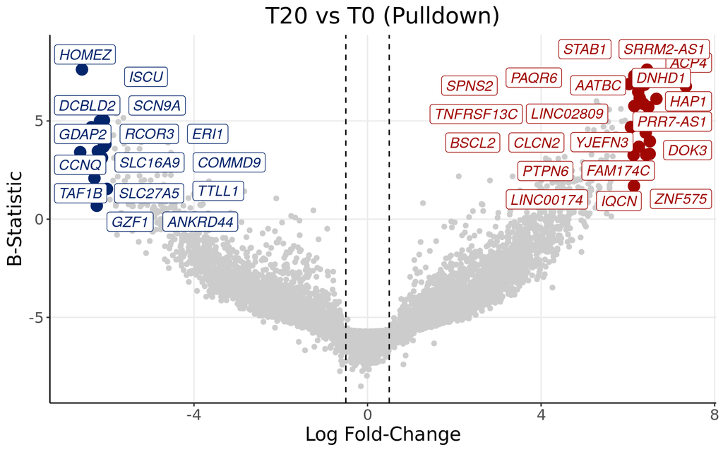

```r
upmarkers <- as.data.frame(DEGenes_T20vsT0[DEGenes_T20vsT0$logFC>6 & DEGenes_T20vsT0$adj.P.Val<0.05,] )
downmarkers <- as.data.frame(DEGenes_T20vsT0[DEGenes_T20vsT0$logFC< -6 & DEGenes_T20vsT0$adj.P.Val<0.05,] )

ggplot(data=DEGenes_T20vsT0,
                 aes(x=logFC,
                     y=  B)) +
  geom_point(color="#CCCCCC")+ geom_vline(xintercept = -0.5, linetype="dashed")+geom_vline(xintercept = 0.5, linetype="dashed")+
  theme_bw() + ylab("B-Statistic")+xlab("Log Fold-Change")+
  theme(axis.line = element_line(colour = "black"),
        panel.grid.minor = element_blank(),
        panel.border = element_blank(),
        panel.background = element_blank()) +
  ggtitle("T20 vs T0 (Pulldown)")+
  theme(plot.title = element_text(hjust = 0.5), plot.subtitle = element_text(hjust = 0.5)) +
  geom_point(data=upmarkers, aes(x=logFC, y=  B), color="#A10702",size=4)+
  geom_point(data=downmarkers, aes(x=logFC, y=  B), color="#03256C",size=4)+
  geom_label_repel(upmarkers[1:ndegs,] , mapping=aes(label=row.names(upmarkers)[1:ndegs]),size=4,point.padding=-0.5, color="#A10702",max.overlaps = 20, fontface="italic")+
  geom_label_repel(downmarkers[1:ndegs,] , mapping=aes(label=row.names(downmarkers)[1:ndegs]),size=4,point.padding=-0.5, color="#03256C",max.overlaps = 20, fontface="italic")+
  theme(text=element_text(size=15,  family="Arial MS"))
```

A bit of a weird shape on the volcano.

## Volcano Plot with Gene Length

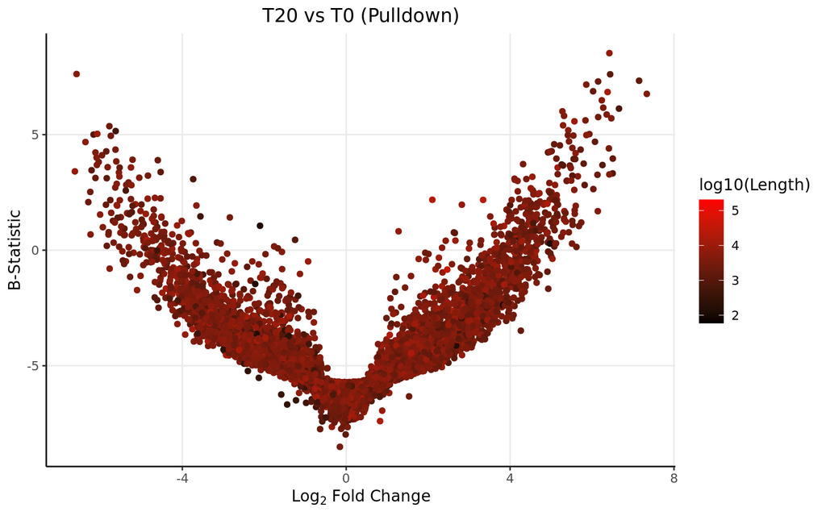

```r
DEGenes_T20vsT0$Gene <- row.names(DEGenes_T20vsT0)
colnames(genelength) <- c("Length","Gene")
DEGenes_T20vsT0 <- merge(DEGenes_T20vsT0, genelength, by="Gene")

ggplot(data=DEGenes_T20vsT0,
                 aes(x=logFC,
                     y=  B)) +
  geom_point(aes(color=log10(Length)))+
  theme_bw() +
  theme(axis.line = element_line(colour = "black"),
        panel.grid.minor = element_blank(),
        panel.border = element_blank(),
        panel.background = element_blank()) +
  ggtitle("T20 vs T0 (Pulldown)")+ xlab(expression(Log[2] ~ Fold ~ Change)) + ylab("B-Statistic") +
  theme(plot.title = element_text(hjust = 0.5))  +
  scale_colour_gradient(low = "black", high = "red")+ theme(text=element_text(family = "Quicksand"))
```

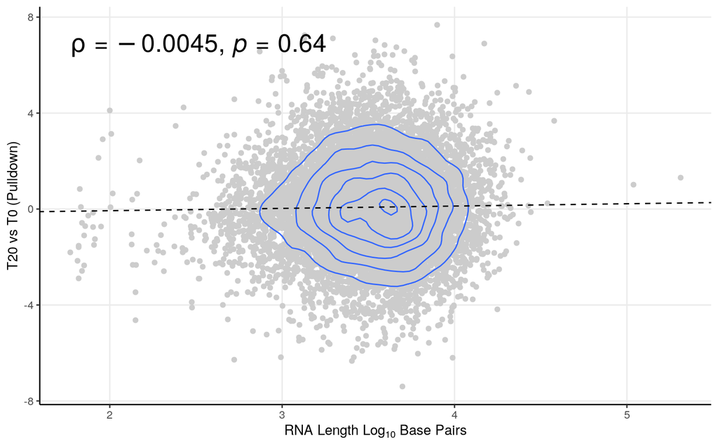

```r
smooth.SG <- lm(t~log10(Length), DEGenes_T20vsT0)
liner.SG <- rstandard(smooth.SG)
DEGenes_T20vsT0 <-cbind(DEGenes_T20vsT0, liner.SG)
colnames(DEGenes_T20vsT0)[9] <- "Residuals"
row.names(DEGenes_T20vsT0) <- DEGenes_T20vsT0$Gene
linemarkers <- as.data.frame(DEGenes_T20vsT0[abs(DEGenes_T20vsT0$Residuals)>4,])

# Calculate the Spearman correlation coefficient
spearman_corr <- cor(DEGenes_T20vsT0$t, log10(DEGenes_T20vsT0$Length), method = "spearman")



ggplot(DEGenes_T20vsT0, aes(y=t, x=log10(Length))) + geom_point(color="#CCCCCC", alpha=1) +   theme_bw()+ geom_density_2d()+
 ylab("T20 vs T0 (Pulldown)") + xlab(expression(RNA ~ Length ~ Log[10] ~ Base ~ Pairs)) +
  theme(axis.line = element_line(colour = "black"),
        panel.grid.minor = element_blank(),
        panel.border = element_blank(),
        panel.background = element_blank()) +
  theme(plot.title = element_text(hjust = 0.5))  +
  geom_abline(slope=smooth.SG$coefficients[2], intercept = smooth.SG$coefficients[1], linetype = "dashed")+ stat_cor(method = "spearman", cor.coef.name = "rho",size=7)
```

If we take this at face value, there is no length bias. By the original authors, on this stress, there should be one.

## Expression Graphs (Extra QC)

As an added control, lets plot these genes in regard to their expression. This helps to see if the expression differences are robust, and not just driven by one sample.

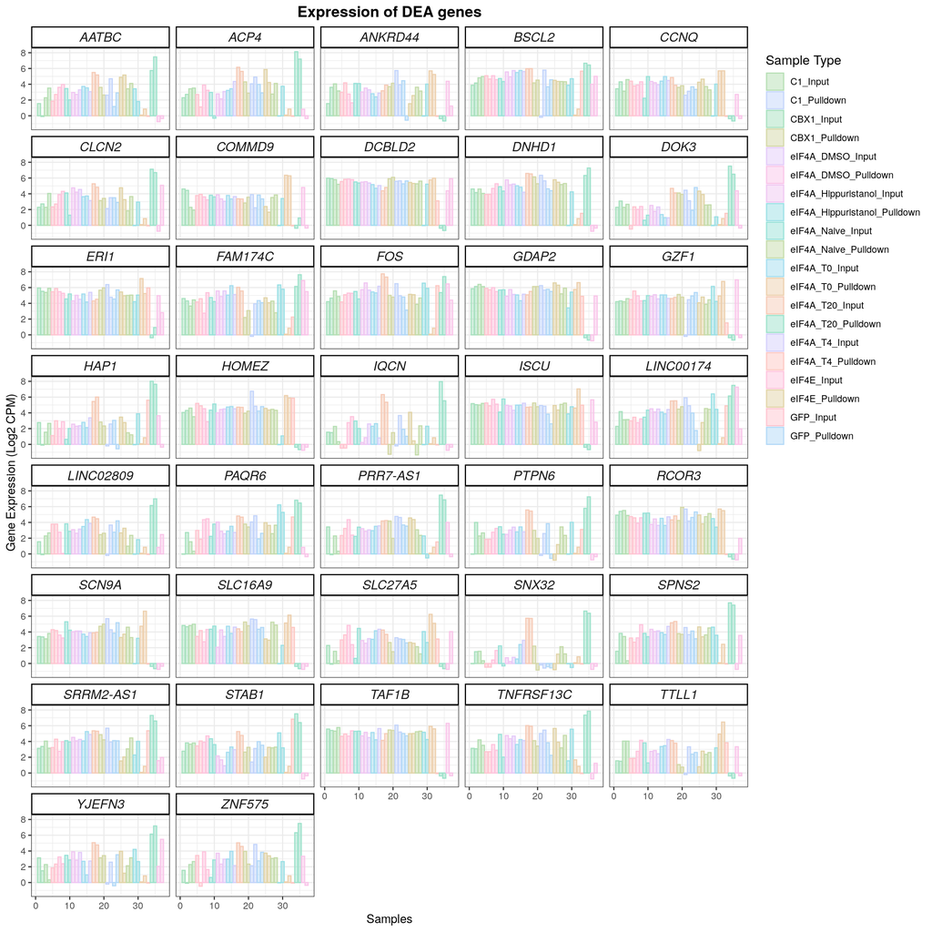

```r
# Define color palette
custom_palette <- qualitative_hcl(20, palette = "Pastel")
custom_palette <- sample(custom_palette, 20)


upmarkers <- as.data.frame(DEGenes_T20vsT0[DEGenes_T20vsT0$logFC>6 & DEGenes_T20vsT0$adj.P.Val<0.05,] )
downmarkers <- as.data.frame(DEGenes_T20vsT0[DEGenes_T20vsT0$logFC< -6 & DEGenes_T20vsT0$adj.P.Val<0.05,] )
finagenes <- rbind(upmarkers, downmarkers)

dfforexpression <- dfforpca
samplecodes <- data.frame(samples=row.names(dfforexpression), purity=c(1:nrow(dfforexpression)))
sampletype <- data.frame(samples=row.names(dfforexpression), sampletype=forall)
dfforexpression <- t(dfforexpression)
genesforexp <- dfforexpression[row.names(dfforexpression)%in%row.names(finagenes),]
genesforexp <- reshape2::melt(genesforexp)
colnames(genesforexp) <- c("Gene", "samples", "expression")
genesforexp <- merge(genesforexp, samplecodes, by="samples")
genesforexp <- merge(genesforexp, sampletype, by="samples")
genesforexp <- genesforexp[,-1]
genesforexp[,2] <- as.numeric(genesforexp[,2])
genesforexp[,1] <- as.character(genesforexp[,1])
genesforexp <- genesforexp[order(genesforexp$Gene),]


winnyplot <- ggplot(genesforexp, aes(x=purity, y=expression, fill=sampletype, colour=sampletype)) + geom_bar(position="dodge", stat="identity", alpha=0.5) + facet_wrap(.~ Gene, ncol=5)
winnyplot <- winnyplot + scale_fill_manual(name = "Sample Type", values = custom_palette) + scale_colour_manual(name = "Sample Type", values = custom_palette)
winnyplot <- winnyplot + theme_bw() + xlab("Samples") + ylab("Gene Expression (Log2 CPM)") + theme(
      strip.text.x = element_text(
        size = 12, face="italic"
        )) +
 theme(
   strip.background = element_rect(
     color="black", fill="#FFFFFF", size=1, linetype="solid"
     )
   ) + theme(
    #legend.position = c(.95, .40),
    legend.justification = c("right", "top"),
    legend.box.just = "right",
    ) + theme(legend.title = element_text(size = 12)) + ggtitle("Expression of DEA genes") + theme(plot.title = element_text(hjust = 0.5, size=14, face="bold"))
winnyplot
```

## GSEA

Now that we have our genes of interest, it would also be interesting to see what are the **altered gene sets** between upregulated and downregulated transcripts from the above comparison. Therefore, lets perform a *Gene Set Enrichment Analysis*

```r
#for all genes
DEGenes_T20vsT0 <- DEGenes_T20vsT0[order(DEGenes_T20vsT0[,4]),]
gseatool <- DEGenes_T20vsT0[,4]
gseatool <- as.data.frame(gseatool)
colnames(gseatool)[1] <- "t"
gseatool[,2] <- DEGenes_T20vsT0$Gene
colnames(gseatool)[2] <- "Symbol"
gseatool <- gseatool[,c(2,1)]

vectorranks <- gseatool$t
names(vectorranks) <- gseatool$Symbol


#to load our pathways
hallmarks.gs <- msigdbr(species = "Homo sapiens", collection =  "H")

hallmarks.gsets <- hallmarks.gs %>% split(x = .$gene_symbol, f = .$gs_name)

for (set in names(hallmarks.gsets)){
  hallmarks.gsets[[set]] <- toupper(hallmarks.gsets[[set]])
}

hallmarks.res <- fgsea(pathways = hallmarks.gsets,
                       stats = vectorranks)
hallmarks.res.tidy <- hallmarks.res %>%
  as_tibble() %>%
  arrange(desc(NES))

hallmarks.res.tidy %>%
  dplyr::select(-leadingEdge, -ES) %>%
  arrange(padj)
```

```
## # A tibble: 50 × 6
##    pathway                                      pval    padj log2err   NES  size
##    <chr>                                       <dbl>   <dbl>   <dbl> <dbl> <int>
##  1 HALLMARK_MYC_TARGETS_V1                  2.83e-10 1.41e-8   0.814 -2.16   188
##  2 HALLMARK_MYOGENESIS                      3.43e- 4 8.59e-3   0.498  1.76    94
##  3 HALLMARK_MTORC1_SIGNALING                5.33e- 4 8.88e-3   0.477 -1.56   174
##  4 HALLMARK_EPITHELIAL_MESENCHYMAL_TRANSIT… 1.45e- 3 1.45e-2   0.455  1.66    91
##  5 HALLMARK_TNFA_SIGNALING_VIA_NFKB         1.33e- 3 1.45e-2   0.455  1.64   107
##  6 HALLMARK_OXIDATIVE_PHOSPHORYLATION       5.21e- 3 4.34e-2   0.407 -1.44   177
##  7 HALLMARK_FATTY_ACID_METABOLISM           7.69e- 3 4.88e-2   0.407 -1.46   109
##  8 HALLMARK_PROTEIN_SECRETION               7.81e- 3 4.88e-2   0.381 -1.49    83
##  9 HALLMARK_INTERFERON_GAMMA_RESPONSE       4.75e- 2 2.64e-1   0.262  1.38    91
## 10 HALLMARK_MYC_TARGETS_V2                  5.59e- 2 2.79e-1   0.322 -1.41    55
## # ℹ 40 more rows
```

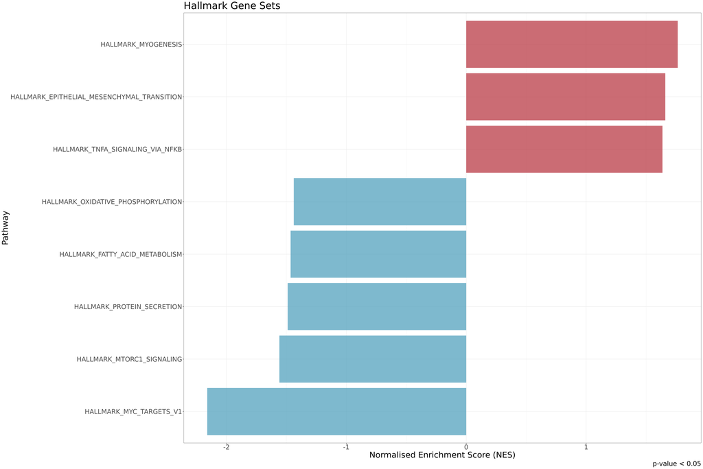

```r
hallmark.sg.t <- hallmarks.res.tidy[,c(1,6)]
hallmark.sg.t <- as.data.frame(hallmark.sg.t)

#this small part is generic
thresh <- 0.05

#this one is no longer generic
data_to_plot <- hallmarks.res.tidy %>% filter(padj < thresh)

statvec <- c()
for (i in 1:nrow(data_to_plot)){
  if (data_to_plot[i,6] > 0){
    status <- "Upregulated"
  }
 else {
   status <- "Downregulated"
 }
statvec <- c(statvec, status)
}

data_to_plot$Status <- statvec

##-----HALMARK-----
gsea_plot_hall <- ggplot(data_to_plot, aes(reorder(pathway, NES), NES)) +
  geom_col(aes(fill= Status), alpha=0.75) + scale_fill_manual(values = c("#53A2BE","#BA3B46"), name = "Regulation Status", labels = c("Downregulated", "Upregulated"), breaks = c("Downregulated", "Upregulated")) +
  coord_flip() +
  labs(x="Pathway", y="Normalised Enrichment Score (NES)",
       title= "Hallmark Gene Sets",
       caption = paste0("p-value < ", thresh)) + theme(plot.title = element_text(hjust = 1)) +
  theme_bw() + theme(text=element_text(family = "Quicksand")) + theme(legend.position = "none")

gsea_plot_hall+
  theme(text=element_text(size=25,  family="Arial MS"))
```

# T20 vs GFP (Pulldown)

## Volcano Plot

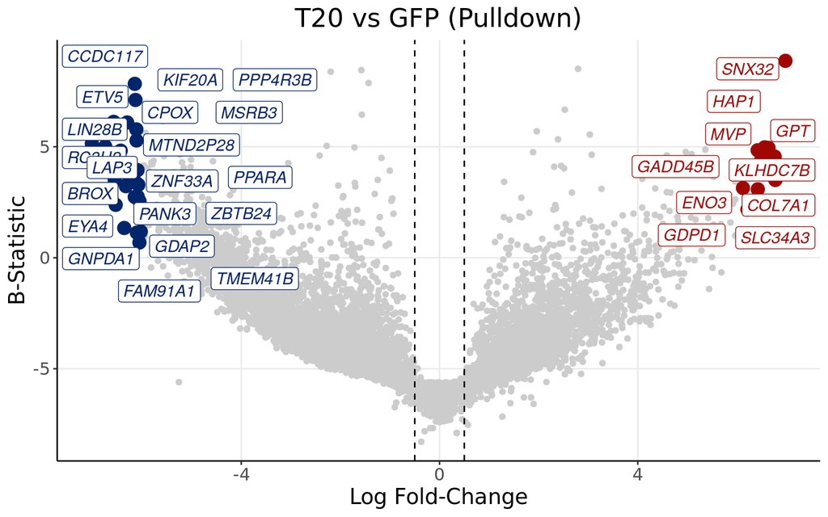

```r
write.table(x = DEGenes_T20vsGFP,
            file = "~/Projects/StressGranules/SGPAPER/SGvsWC/APadron_Heatshock.txt", sep="\t", col.names = TRUE, row.names = TRUE, quote=FALSE)

upmarkers <- as.data.frame(DEGenes_T20vsGFP[DEGenes_T20vsGFP$logFC>6 & DEGenes_T20vsGFP$adj.P.Val<0.05,] )
downmarkers <- as.data.frame(DEGenes_T20vsGFP[DEGenes_T20vsGFP$logFC< -6 & DEGenes_T20vsGFP$adj.P.Val<0.05,] )

ggplot(data=DEGenes_T20vsGFP,
                 aes(x=logFC,
                     y=  B)) +
  geom_point(color="#CCCCCC")+ geom_vline(xintercept = -0.5, linetype="dashed")+geom_vline(xintercept = 0.5, linetype="dashed")+
  theme_bw() + ylab("B-Statistic")+xlab("Log Fold-Change")+
  theme(axis.line = element_line(colour = "black"),
        panel.grid.minor = element_blank(),
        panel.border = element_blank(),
        panel.background = element_blank()) +
  ggtitle("T20 vs GFP (Pulldown)")+
  theme(plot.title = element_text(hjust = 0.5), plot.subtitle = element_text(hjust = 0.5)) +
  geom_point(data=upmarkers, aes(x=logFC, y=  B), color="#A10702",size=4)+
  geom_point(data=downmarkers, aes(x=logFC, y=  B), color="#03256C",size=4)+
  geom_label_repel(upmarkers[1:ndegs,] , mapping=aes(label=row.names(upmarkers)[1:ndegs]),size=4,point.padding=-0.5, color="#A10702",max.overlaps = 20, fontface="italic")+
  geom_label_repel(downmarkers[1:ndegs,] , mapping=aes(label=row.names(downmarkers)[1:ndegs]),size=4,point.padding=-0.5, color="#03256C",max.overlaps = 20, fontface="italic")+
  theme(text=element_text(size=15,  family="Arial MS"))
```

A bit of a weird shape on the volcano.

## Volcano Plot with Gene Length

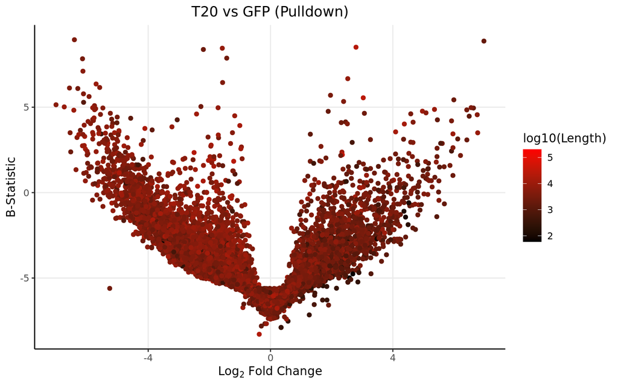

```r
DEGenes_T20vsGFP$Gene <- row.names(DEGenes_T20vsGFP)
colnames(genelength) <- c("Length","Gene")
DEGenes_T20vsGFP <- merge(DEGenes_T20vsGFP, genelength, by="Gene")

ggplot(data=DEGenes_T20vsGFP,
                 aes(x=logFC,
                     y=  B)) +
  geom_point(aes(color=log10(Length)))+
  theme_bw() +
  theme(axis.line = element_line(colour = "black"),
        panel.grid.minor = element_blank(),
        panel.border = element_blank(),
        panel.background = element_blank()) +
  ggtitle("T20 vs GFP (Pulldown)")+ xlab(expression(Log[2] ~ Fold ~ Change)) + ylab("B-Statistic") +
  theme(plot.title = element_text(hjust = 0.5))  +
  scale_colour_gradient(low = "black", high = "red")+ theme(text=element_text(family = "Quicksand"))
```

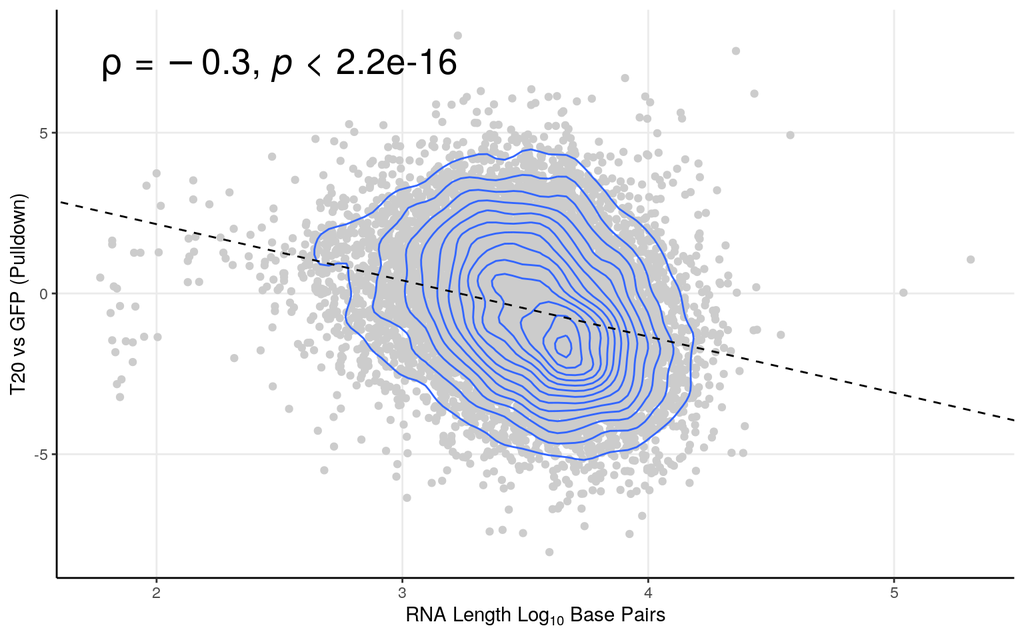

```r
smooth.SG <- lm(t~log10(Length), DEGenes_T20vsGFP)
liner.SG <- rstandard(smooth.SG)
DEGenes_T20vsGFP <-cbind(DEGenes_T20vsGFP, liner.SG)
colnames(DEGenes_T20vsGFP)[9] <- "Residuals"
row.names(DEGenes_T20vsGFP) <- DEGenes_T20vsGFP$Gene
linemarkers <- as.data.frame(DEGenes_T20vsGFP[abs(DEGenes_T20vsGFP$Residuals)>4,])

# Calculate the Spearman correlation coefficient
spearman_corr <- cor(DEGenes_T20vsGFP$t, log10(DEGenes_T20vsGFP$Length), method = "spearman")



ggplot(DEGenes_T20vsGFP, aes(y=t, x=log10(Length))) + geom_point(color="#CCCCCC", alpha=1) +   theme_bw()+ geom_density_2d()+
 ylab("T20 vs GFP (Pulldown)") + xlab(expression(RNA ~ Length ~ Log[10] ~ Base ~ Pairs)) +
  theme(axis.line = element_line(colour = "black"),
        panel.grid.minor = element_blank(),
        panel.border = element_blank(),
        panel.background = element_blank()) +
  theme(plot.title = element_text(hjust = 0.5))  +
  geom_abline(slope=smooth.SG$coefficients[2], intercept = smooth.SG$coefficients[1], linetype = "dashed")+ stat_cor(method = "spearman", cor.coef.name = "rho",size=7)
```

Comparing with the cytoplasm, it seems we have a negative lenght bias.

## Expression Graphs (Extra QC)

As an added control, lets plot these genes in regard to their expression, and contamination.

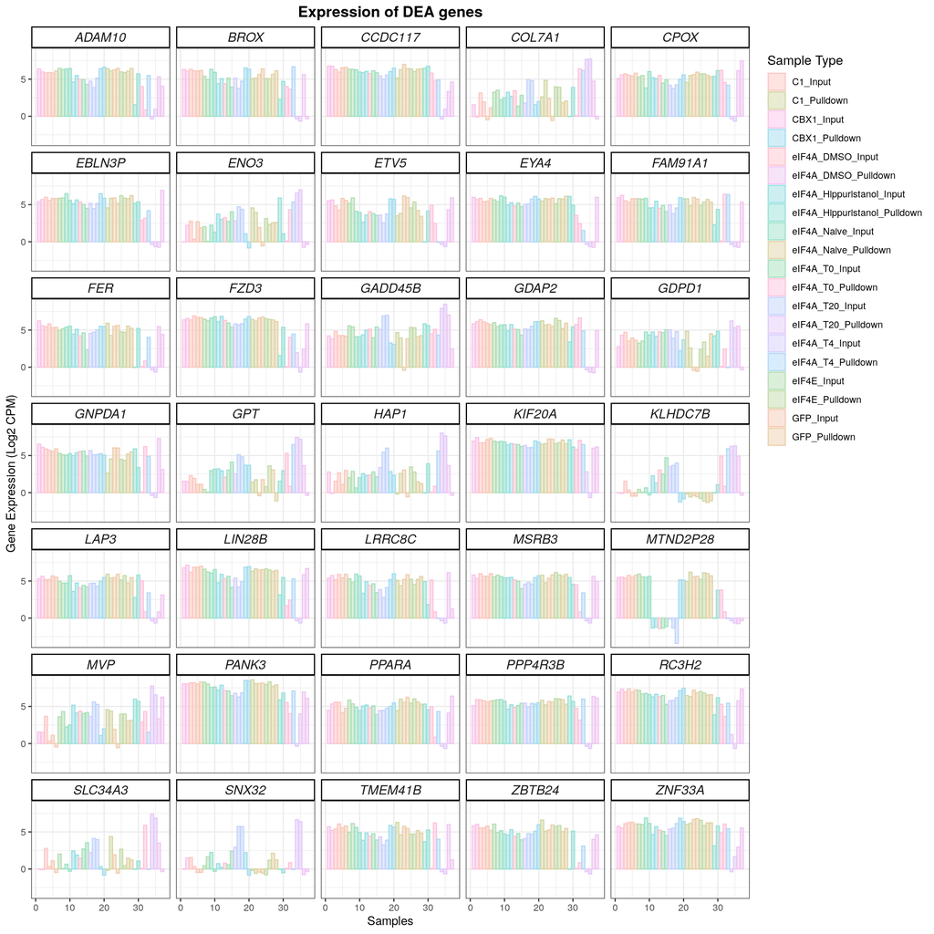

```r
# Define color palette
custom_palette <- qualitative_hcl(20, palette = "Pastel")
custom_palette <- sample(custom_palette, 20)


upmarkers <- as.data.frame(DEGenes_T20vsGFP[DEGenes_T20vsGFP$logFC>6 & DEGenes_T20vsGFP$adj.P.Val<0.05,] )
downmarkers <- as.data.frame(DEGenes_T20vsGFP[DEGenes_T20vsGFP$logFC< -6 & DEGenes_T20vsGFP$adj.P.Val<0.05,] )
finagenes <- rbind(upmarkers, downmarkers)

dfforexpression <- dfforpca
samplecodes <- data.frame(samples=row.names(dfforexpression), purity=c(1:nrow(dfforexpression)))
sampletype <- data.frame(samples=row.names(dfforexpression), sampletype=forall)
dfforexpression <- t(dfforexpression)
genesforexp <- dfforexpression[row.names(dfforexpression)%in%row.names(finagenes),]
genesforexp <- reshape2::melt(genesforexp)
colnames(genesforexp) <- c("Gene", "samples", "expression")
genesforexp <- merge(genesforexp, samplecodes, by="samples")
genesforexp <- merge(genesforexp, sampletype, by="samples")
genesforexp <- genesforexp[,-1]
genesforexp[,2] <- as.numeric(genesforexp[,2])
genesforexp[,1] <- as.character(genesforexp[,1])
genesforexp <- genesforexp[order(genesforexp$Gene),]


winnyplot <- ggplot(genesforexp, aes(x=purity, y=expression, fill=sampletype, colour=sampletype)) + geom_bar(position="dodge", stat="identity", alpha=0.5) + facet_wrap(.~ Gene, ncol=5)
winnyplot <- winnyplot + scale_fill_manual(name = "Sample Type", values = custom_palette) + scale_colour_manual(name = "Sample Type", values = custom_palette)
winnyplot <- winnyplot + theme_bw() + xlab("Samples") + ylab("Gene Expression (Log2 CPM)") + theme(
      strip.text.x = element_text(
        size = 12, face="italic"
        )) +
 theme(
   strip.background = element_rect(
     color="black", fill="#FFFFFF", size=1, linetype="solid"
     )
   ) + theme(
    #legend.position = c(.95, .40),
    legend.justification = c("right", "top"),
    legend.box.just = "right",
    ) + theme(legend.title = element_text(size = 12)) + ggtitle("Expression of DEA genes") + theme(plot.title = element_text(hjust = 0.5, size=14, face="bold"))
winnyplot
```

## GSEA

```r
#for all genes
DEGenes_T20vsGFP <- DEGenes_T20vsGFP[order(DEGenes_T20vsGFP[,4]),]
gseatool <- DEGenes_T20vsGFP[,4]
gseatool <- as.data.frame(gseatool)
colnames(gseatool)[1] <- "t"
gseatool[,2] <- DEGenes_T20vsGFP$Gene
colnames(gseatool)[2] <- "Symbol"
gseatool <- gseatool[,c(2,1)]

vectorranks <- gseatool$t
names(vectorranks) <- gseatool$Symbol


#to load our pathways
hallmarks.gs <- msigdbr(species = "Homo sapiens", collection =  "H")

hallmarks.gsets <- hallmarks.gs %>% split(x = .$gene_symbol, f = .$gs_name)

for (set in names(hallmarks.gsets)){
  hallmarks.gsets[[set]] <- toupper(hallmarks.gsets[[set]])
}

hallmarks.res <- fgsea(pathways = hallmarks.gsets,
                       stats = vectorranks)
```

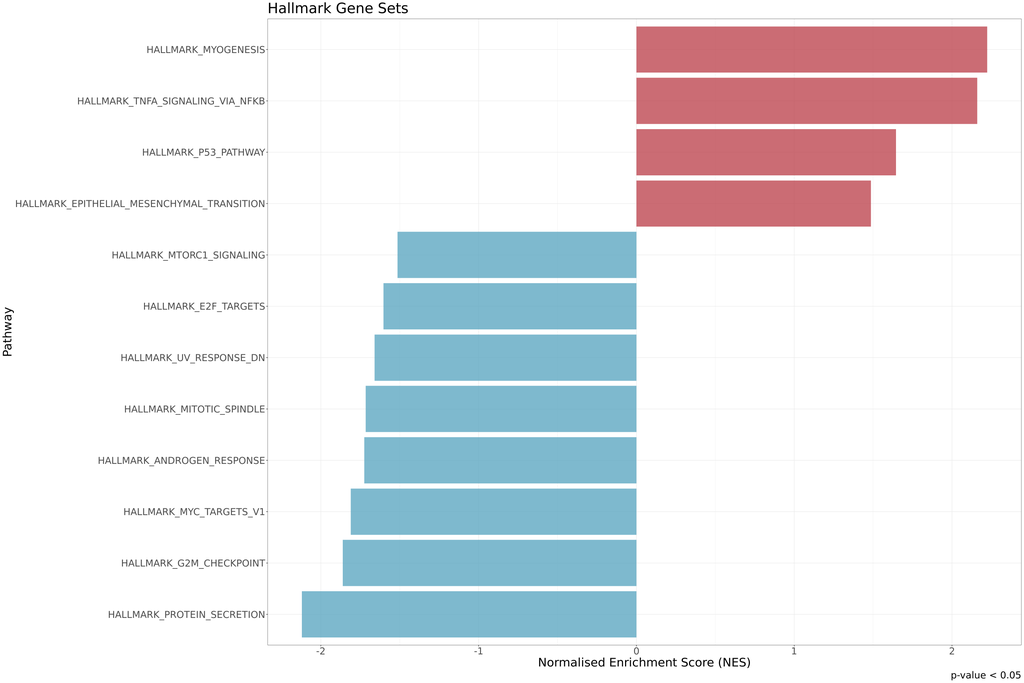

```r
hallmarks.res.tidy <- hallmarks.res %>%
  as_tibble() %>%
  arrange(desc(NES))

hallmarks.res.tidy %>%
  dplyr::select(-leadingEdge, -ES) %>%
  arrange(padj)

hallmark.sg.t <- hallmarks.res.tidy[,c(1,6)]
hallmark.sg.t <- as.data.frame(hallmark.sg.t)

#this small part is generic
thresh <- 0.05

#this one is no longer generic
data_to_plot <- hallmarks.res.tidy %>% filter(padj < thresh)

statvec <- c()
for (i in 1:nrow(data_to_plot)){
  if (data_to_plot[i,6] > 0){
    status <- "Upregulated"
  }
 else {
   status <- "Downregulated"
 }
statvec <- c(statvec, status)
}

data_to_plot$Status <- statvec

##-----HALMARK-----
gsea_plot_hall <- ggplot(data_to_plot, aes(reorder(pathway, NES), NES)) +
  geom_col(aes(fill= Status), alpha=0.75) + scale_fill_manual(values = c("#53A2BE","#BA3B46"), name = "Regulation Status", labels = c("Downregulated", "Upregulated"), breaks = c("Downregulated", "Upregulated")) +
  coord_flip() +
  labs(x="Pathway", y="Normalised Enrichment Score (NES)",
       title= "Hallmark Gene Sets",
       caption = paste0("p-value < ", thresh)) + theme(plot.title = element_text(hjust = 1)) +
  theme_bw() + theme(text=element_text(family = "Quicksand")) + theme(legend.position = "none")

gsea_plot_hall+
  theme(text=element_text(size=25,  family="Arial MS"))
```

# T20 vs DMSO (Pulldown)

## Volcano Plot

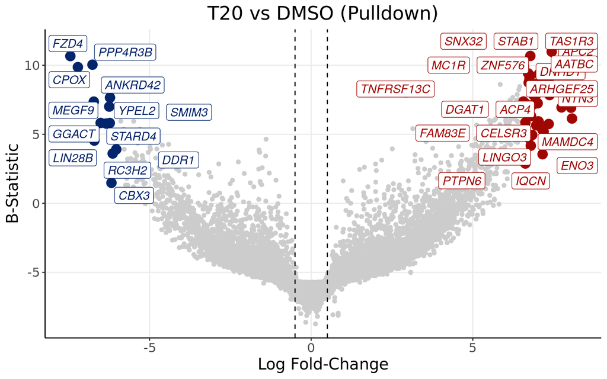

```r
upmarkers <- as.data.frame(DEGenes_T20vsDMSO[DEGenes_T20vsDMSO$logFC>6.5 & DEGenes_T20vsDMSO$adj.P.Val<0.05,] )
downmarkers <- as.data.frame(DEGenes_T20vsDMSO[DEGenes_T20vsDMSO$logFC< -6 & DEGenes_T20vsDMSO$adj.P.Val<0.05,] )

ggplot(data=DEGenes_T20vsDMSO,
                 aes(x=logFC,
                     y=  B)) +
  geom_point(color="#CCCCCC")+ geom_vline(xintercept = -0.5, linetype="dashed")+geom_vline(xintercept = 0.5, linetype="dashed")+
  theme_bw() + ylab("B-Statistic")+xlab("Log Fold-Change")+
  theme(axis.line = element_line(colour = "black"),
        panel.grid.minor = element_blank(),
        panel.border = element_blank(),
        panel.background = element_blank()) +
  ggtitle("T20 vs DMSO (Pulldown)")+
  theme(plot.title = element_text(hjust = 0.5), plot.subtitle = element_text(hjust = 0.5)) +
  geom_point(data=upmarkers, aes(x=logFC, y=  B), color="#A10702",size=4)+
  geom_point(data=downmarkers, aes(x=logFC, y=  B), color="#03256C",size=4)+
  geom_label_repel(upmarkers[1:ndegs,] , mapping=aes(label=row.names(upmarkers)[1:ndegs]),size=4,point.padding=-0.5, color="#A10702",max.overlaps = 20, fontface="italic")+
  geom_label_repel(downmarkers[1:ndegs,] , mapping=aes(label=row.names(downmarkers)[1:ndegs]),size=4,point.padding=-0.5, color="#03256C",max.overlaps = 20, fontface="italic")+
  theme(text=element_text(size=15,  family="Arial MS"))
```

## Volcano Plot with Gene Length

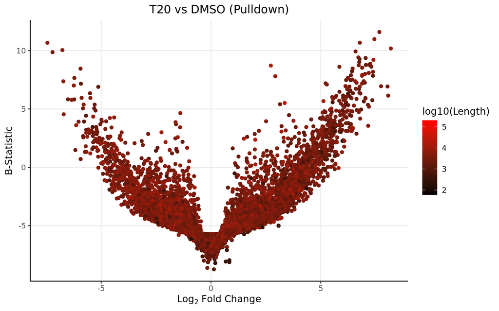

```r
DEGenes_T20vsDMSO$Gene <- row.names(DEGenes_T20vsDMSO)
colnames(genelength) <- c("Length","Gene")
DEGenes_T20vsDMSO <- merge(DEGenes_T20vsDMSO, genelength, by="Gene")

ggplot(data=DEGenes_T20vsDMSO,
                 aes(x=logFC,
                     y=  B)) +
  geom_point(aes(color=log10(Length)))+
  theme_bw() +
  theme(axis.line = element_line(colour = "black"),
        panel.grid.minor = element_blank(),
        panel.border = element_blank(),
        panel.background = element_blank()) +
  ggtitle("T20 vs DMSO (Pulldown)")+ xlab(expression(Log[2] ~ Fold ~ Change)) + ylab("B-Statistic") +
  theme(plot.title = element_text(hjust = 0.5))  +
  scale_colour_gradient(low = "black", high = "red")+ theme(text=element_text(family = "Quicksand"))
```

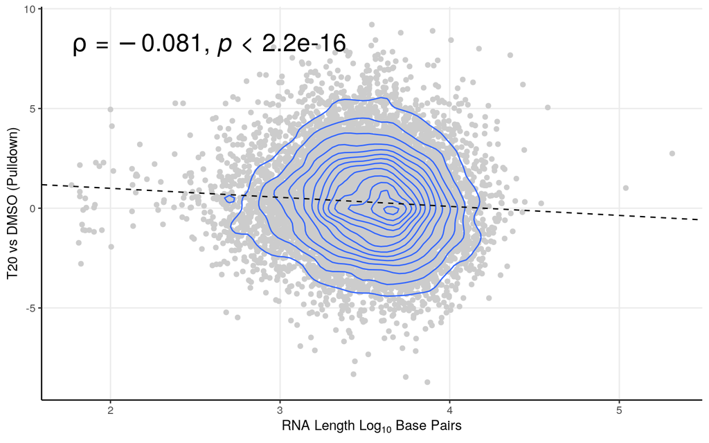

```r
smooth.SG <- lm(t~log10(Length), DEGenes_T20vsDMSO)
liner.SG <- rstandard(smooth.SG)
DEGenes_T20vsDMSO <-cbind(DEGenes_T20vsDMSO, liner.SG)
colnames(DEGenes_T20vsDMSO)[9] <- "Residuals"
row.names(DEGenes_T20vsDMSO) <- DEGenes_T20vsDMSO$Gene
linemarkers <- as.data.frame(DEGenes_T20vsDMSO[abs(DEGenes_T20vsDMSO$Residuals)>4,])

# Calculate the Spearman correlation coefficient
spearman_corr <- cor(DEGenes_T20vsDMSO$t, log10(DEGenes_T20vsDMSO$Length), method = "spearman")



ggplot(DEGenes_T20vsDMSO, aes(y=t, x=log10(Length))) + geom_point(color="#CCCCCC", alpha=1) +   theme_bw()+ geom_density_2d()+
 ylab("T20 vs DMSO (Pulldown)") + xlab(expression(RNA ~ Length ~ Log[10] ~ Base ~ Pairs)) +
  theme(axis.line = element_line(colour = "black"),
        panel.grid.minor = element_blank(),
        panel.border = element_blank(),
        panel.background = element_blank()) +
  theme(plot.title = element_text(hjust = 0.5))  +
  geom_abline(slope=smooth.SG$coefficients[2], intercept = smooth.SG$coefficients[1], linetype = "dashed")+ stat_cor(method = "spearman", cor.coef.name = "rho",size=7)
```

This way, there doesn’t seem to be a lenght bias.

## Expression Graphs (Extra QC)

As an added control, lets plot these genes in regard to their expression, and contamination.

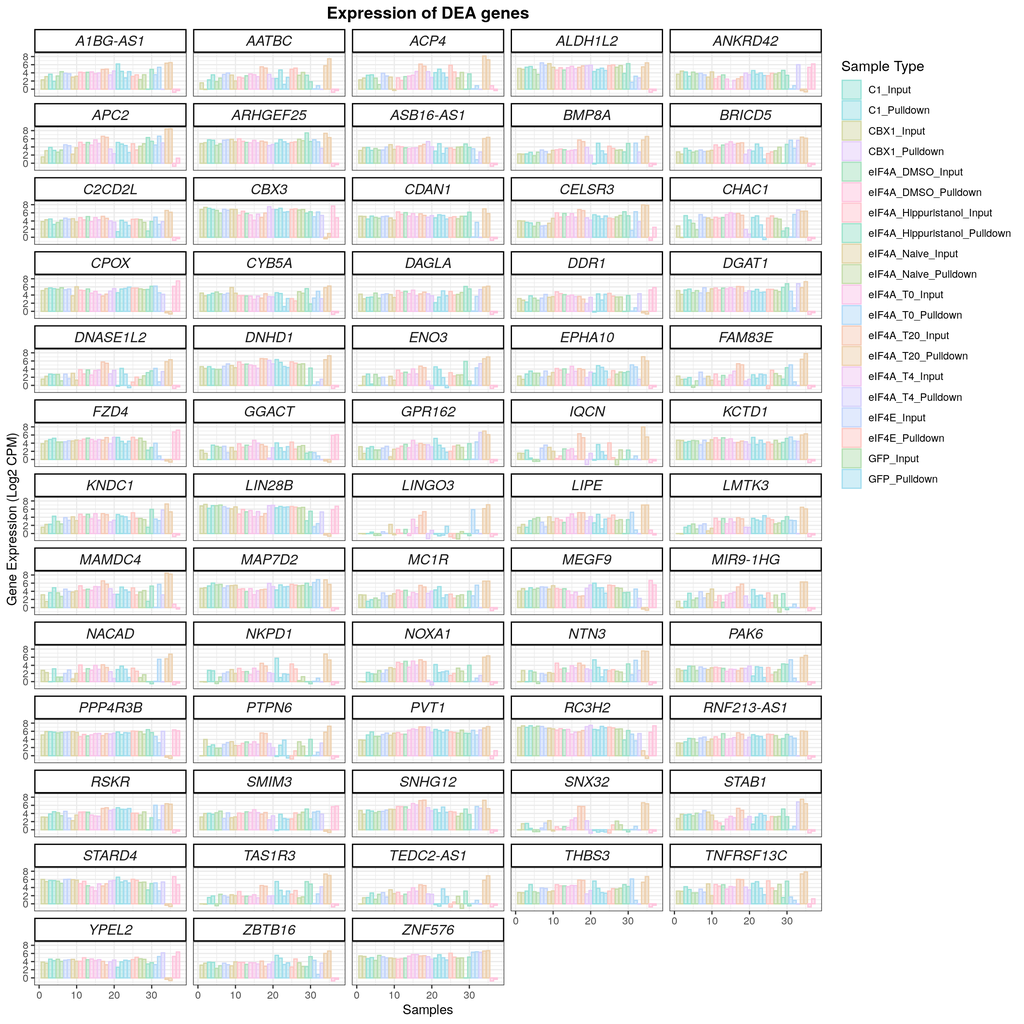

```r
# Define color palette
custom_palette <- qualitative_hcl(20, palette = "Pastel")
custom_palette <- sample(custom_palette, 20)


upmarkers <- as.data.frame(DEGenes_T20vsDMSO[DEGenes_T20vsDMSO$logFC>6.5 & DEGenes_T20vsDMSO$adj.P.Val<0.05,] )
downmarkers <- as.data.frame(DEGenes_T20vsDMSO[DEGenes_T20vsDMSO$logFC< -6 & DEGenes_T20vsDMSO$adj.P.Val<0.05,] )

finagenes <- rbind(upmarkers, downmarkers)

dfforexpression <- dfforpca
samplecodes <- data.frame(samples=row.names(dfforexpression), purity=c(1:nrow(dfforexpression)))
sampletype <- data.frame(samples=row.names(dfforexpression), sampletype=forall)
dfforexpression <- t(dfforexpression)
genesforexp <- dfforexpression[row.names(dfforexpression)%in%row.names(finagenes),]
genesforexp <- reshape2::melt(genesforexp)
colnames(genesforexp) <- c("Gene", "samples", "expression")
genesforexp <- merge(genesforexp, samplecodes, by="samples")
genesforexp <- merge(genesforexp, sampletype, by="samples")
genesforexp <- genesforexp[,-1]
genesforexp[,2] <- as.numeric(genesforexp[,2])
genesforexp[,1] <- as.character(genesforexp[,1])
genesforexp <- genesforexp[order(genesforexp$Gene),]


winnyplot <- ggplot(genesforexp, aes(x=purity, y=expression, fill=sampletype, colour=sampletype)) + geom_bar(position="dodge", stat="identity", alpha=0.5) + facet_wrap(.~ Gene, ncol=5)
winnyplot <- winnyplot + scale_fill_manual(name = "Sample Type", values = custom_palette) + scale_colour_manual(name = "Sample Type", values = custom_palette)
winnyplot <- winnyplot + theme_bw() + xlab("Samples") + ylab("Gene Expression (Log2 CPM)") + theme(
      strip.text.x = element_text(
        size = 12, face="italic"
        )) +
 theme(
   strip.background = element_rect(
     color="black", fill="#FFFFFF", size=1, linetype="solid"
     )
   ) + theme(
    #legend.position = c(.95, .40),
    legend.justification = c("right", "top"),
    legend.box.just = "right",
    ) + theme(legend.title = element_text(size = 12)) + ggtitle("Expression of DEA genes") + theme(plot.title = element_text(hjust = 0.5, size=14, face="bold"))
winnyplot
```

## GSEA

```r
#for all genes
DEGenes_T20vsDMSO <- DEGenes_T20vsDMSO[order(DEGenes_T20vsDMSO[,4]),]
gseatool <- DEGenes_T20vsDMSO[,4]
gseatool <- as.data.frame(gseatool)
colnames(gseatool)[1] <- "t"
gseatool[,2] <- DEGenes_T20vsDMSO$Gene
colnames(gseatool)[2] <- "Symbol"
gseatool <- gseatool[,c(2,1)]

vectorranks <- gseatool$t
names(vectorranks) <- gseatool$Symbol


#to load our pathways
hallmarks.gs <- msigdbr(species = "Homo sapiens", collection =  "H")

hallmarks.gsets <- hallmarks.gs %>% split(x = .$gene_symbol, f = .$gs_name)

for (set in names(hallmarks.gsets)){
  hallmarks.gsets[[set]] <- toupper(hallmarks.gsets[[set]])
}

hallmarks.res <- fgsea(pathways = hallmarks.gsets,
                       stats = vectorranks)
```

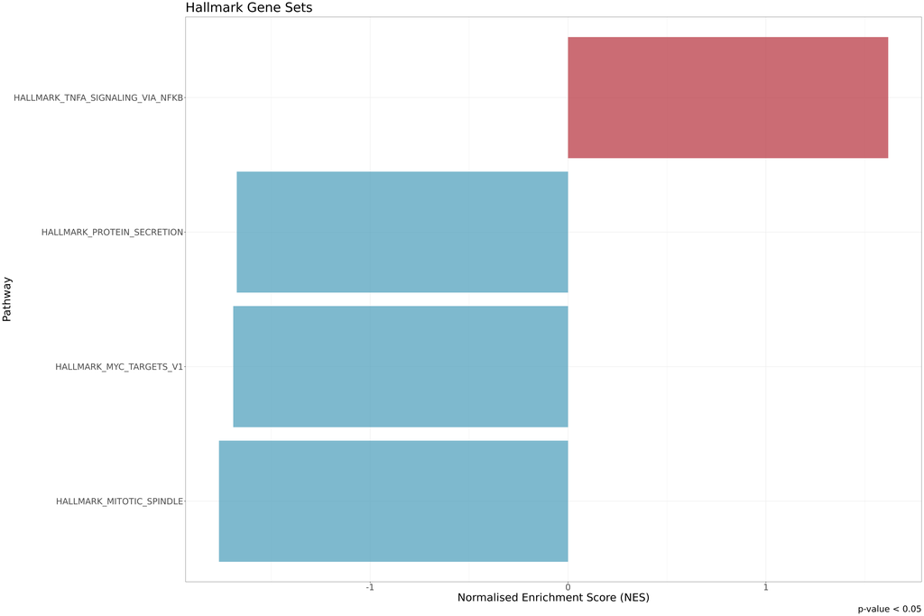

```r
hallmarks.res.tidy <- hallmarks.res %>%
  as_tibble() %>%
  arrange(desc(NES))

hallmarks.res.tidy %>%
  dplyr::select(-leadingEdge, -ES) %>%
  arrange(padj)

hallmark.sg.t <- hallmarks.res.tidy[,c(1,6)]
hallmark.sg.t <- as.data.frame(hallmark.sg.t)

#this small part is generic
thresh <- 0.05

#this one is no longer generic
data_to_plot <- hallmarks.res.tidy %>% filter(padj < thresh)

statvec <- c()
for (i in 1:nrow(data_to_plot)){
  if (data_to_plot[i,6] > 0){
    status <- "Upregulated"
  }
 else {
   status <- "Downregulated"
 }
statvec <- c(statvec, status)
}

data_to_plot$Status <- statvec

##-----HALMARK-----
gsea_plot_hall <- ggplot(data_to_plot, aes(reorder(pathway, NES), NES)) +
  geom_col(aes(fill= Status), alpha=0.75) + scale_fill_manual(values = c("#53A2BE","#BA3B46"), name = "Regulation Status", labels = c("Downregulated", "Upregulated"), breaks = c("Downregulated", "Upregulated")) +
  coord_flip() +
  labs(x="Pathway", y="Normalised Enrichment Score (NES)",
       title= "Hallmark Gene Sets",
       caption = paste0("p-value < ", thresh)) + theme(plot.title = element_text(hjust = 1)) +
  theme_bw() + theme(text=element_text(family = "Quicksand")) + theme(legend.position = "none")

gsea_plot_hall+
  theme(text=element_text(size=25,  family="Arial MS"))
```

# T20 vs T20

## Volcano Plot

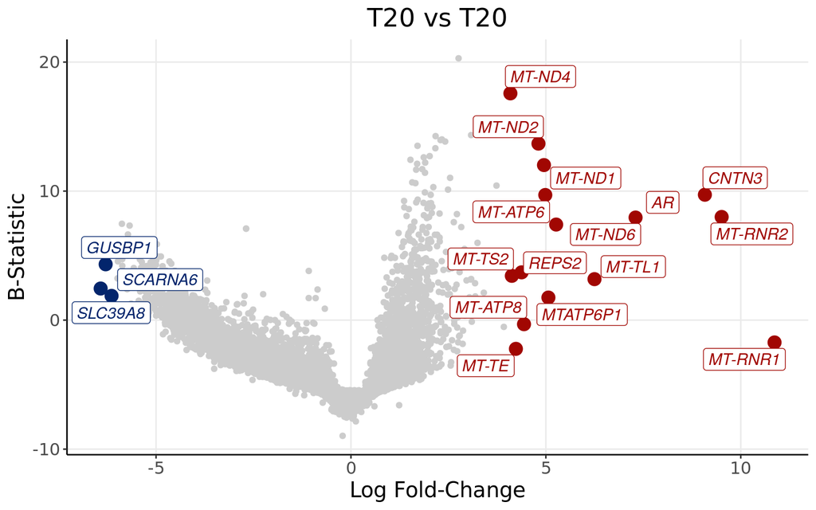

```r
upmarkers <- as.data.frame(DEGenes_T20vsT20[DEGenes_T20vsT20$logFC>4 & DEGenes_T20vsT20$adj.P.Val<0.05,] )
downmarkers <- as.data.frame(DEGenes_T20vsT20[DEGenes_T20vsT20$logFC< -6 & DEGenes_T20vsT20$adj.P.Val<0.05,] )

ggplot(data=DEGenes_T20vsT20,
                 aes(x=logFC,
                     y=  B)) +
  geom_point(color="#CCCCCC")+
  theme_bw() + ylab("B-Statistic")+xlab("Log Fold-Change")+
  theme(axis.line = element_line(colour = "black"),
        panel.grid.minor = element_blank(),
        panel.border = element_blank(),
        panel.background = element_blank()) +
  ggtitle("T20 vs T20")+
  theme(plot.title = element_text(hjust = 0.5), plot.subtitle = element_text(hjust = 0.5)) +
  geom_point(data=upmarkers, aes(x=logFC, y=  B), color="#A10702",size=4)+
  geom_point(data=downmarkers, aes(x=logFC, y=  B), color="#03256C",size=4)+
  geom_label_repel(upmarkers[1:ndegs,] , mapping=aes(label=row.names(upmarkers)[1:ndegs]),size=4,point.padding=-0.5, color="#A10702",max.overlaps = 20, fontface="italic")+
  geom_label_repel(downmarkers[1:ndegs,] , mapping=aes(label=row.names(downmarkers)[1:ndegs]),size=4,point.padding=-0.5, color="#03256C",max.overlaps = 20, fontface="italic")+
  theme(text=element_text(size=15,  family="Arial MS"))
```

Like this, most enriched transcripts are all mitochondrial in origin, which is what I also see with my corrected DC data.

## Volcano Plot with Gene Length

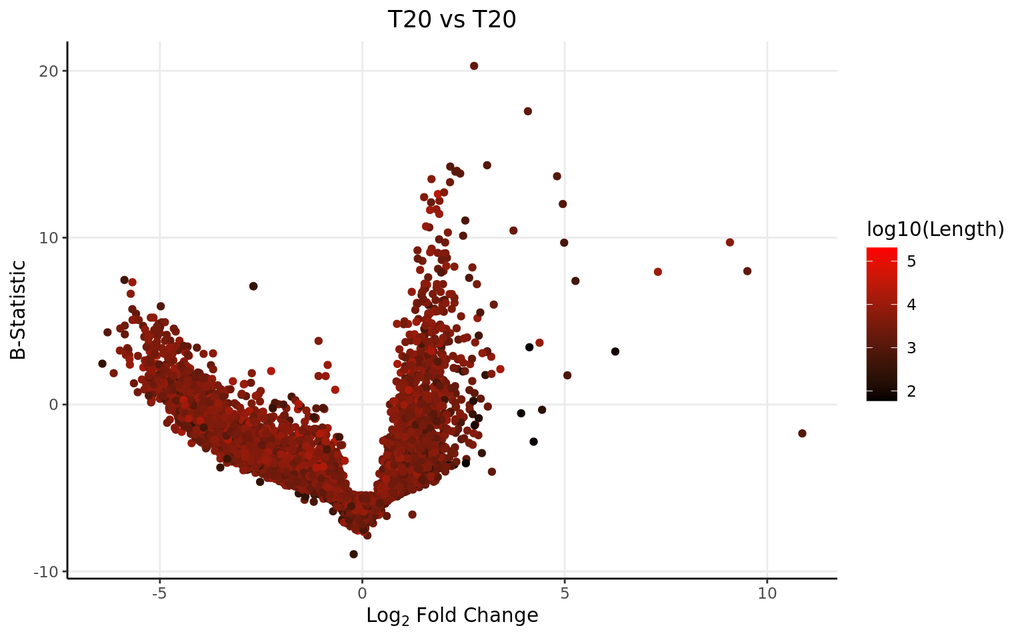

```r
DEGenes_T20vsT20$Gene <- row.names(DEGenes_T20vsT20)
colnames(genelength) <- c("Length","Gene")
DEGenes_T20vsT20 <- merge(DEGenes_T20vsT20, genelength, by="Gene")

ggplot(data=DEGenes_T20vsT20,
                 aes(x=logFC,
                     y=  B)) +
  geom_point(aes(color=log10(Length)))+
  theme_bw() +
  theme(axis.line = element_line(colour = "black"),
        panel.grid.minor = element_blank(),
        panel.border = element_blank(),
        panel.background = element_blank()) +
  ggtitle("T20 vs T20")+ xlab(expression(Log[2] ~ Fold ~ Change)) + ylab("B-Statistic") +
  theme(plot.title = element_text(hjust = 0.5))  +
  scale_colour_gradient(low = "black", high = "red")+ theme(text=element_text(family = "Quicksand"))
```

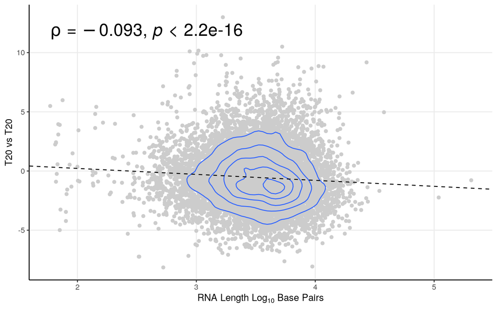

```r
smooth.SG <- lm(t~log10(Length), DEGenes_T20vsT20)
liner.SG <- rstandard(smooth.SG)
DEGenes_T20vsT20 <-cbind(DEGenes_T20vsT20, liner.SG)
colnames(DEGenes_T20vsT20)[9] <- "Residuals"
row.names(DEGenes_T20vsT20) <- DEGenes_T20vsT20$Gene
linemarkers <- as.data.frame(DEGenes_T20vsT20[abs(DEGenes_T20vsT20$Residuals)>4,])

# Calculate the Spearman correlation coefficient
spearman_corr <- cor(DEGenes_T20vsT20$t, log10(DEGenes_T20vsT20$Length), method = "spearman")



ggplot(DEGenes_T20vsT20, aes(y=t, x=log10(Length))) + geom_point(color="#CCCCCC", alpha=1) +   theme_bw()+ geom_density_2d()+
 ylab("T20 vs T20") + xlab(expression(RNA ~ Length ~ Log[10] ~ Base ~ Pairs)) +
  theme(axis.line = element_line(colour = "black"),
        panel.grid.minor = element_blank(),
        panel.border = element_blank(),
        panel.background = element_blank()) +
  theme(plot.title = element_text(hjust = 0.5))  +
  geom_abline(slope=smooth.SG$coefficients[2], intercept = smooth.SG$coefficients[1], linetype = "dashed")+ stat_cor(method = "spearman", cor.coef.name = "rho",size=7)
```

No lenght bias.

## Expression Graphs (Extra QC)

As an added control, lets plot these genes in regard to their expression, and contamination.

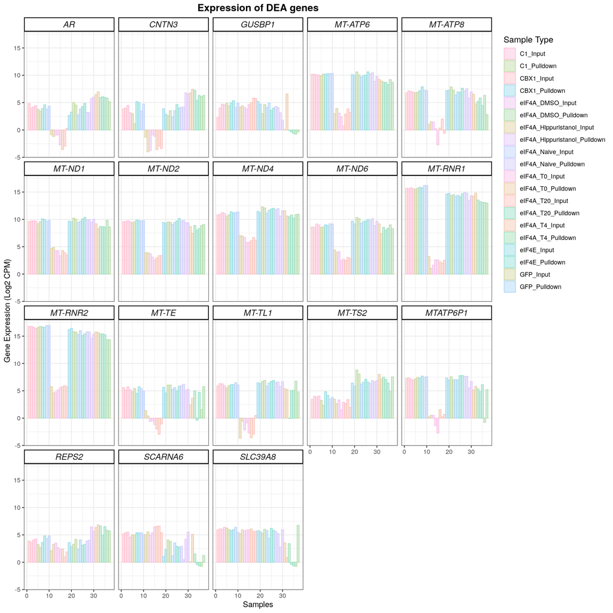

```r
# Define color palette
custom_palette <- qualitative_hcl(20, palette = "Pastel")
custom_palette <- sample(custom_palette, 20)


upmarkers <- as.data.frame(DEGenes_T20vsT20[DEGenes_T20vsT20$logFC>4 & DEGenes_T20vsT20$adj.P.Val<0.05,] )
downmarkers <- as.data.frame(DEGenes_T20vsT20[DEGenes_T20vsT20$logFC< -6 & DEGenes_T20vsT20$adj.P.Val<0.05,] )

finagenes <- rbind(upmarkers, downmarkers)

dfforexpression <- dfforpca
samplecodes <- data.frame(samples=row.names(dfforexpression), purity=c(1:nrow(dfforexpression)))
sampletype <- data.frame(samples=row.names(dfforexpression), sampletype=forall)
dfforexpression <- t(dfforexpression)
genesforexp <- dfforexpression[row.names(dfforexpression)%in%row.names(finagenes),]
genesforexp <- reshape2::melt(genesforexp)
colnames(genesforexp) <- c("Gene", "samples", "expression")
genesforexp <- merge(genesforexp, samplecodes, by="samples")
genesforexp <- merge(genesforexp, sampletype, by="samples")
genesforexp <- genesforexp[,-1]
genesforexp[,2] <- as.numeric(genesforexp[,2])
genesforexp[,1] <- as.character(genesforexp[,1])
genesforexp <- genesforexp[order(genesforexp$Gene),]


winnyplot <- ggplot(genesforexp, aes(x=purity, y=expression, fill=sampletype, colour=sampletype)) + geom_bar(position="dodge", stat="identity", alpha=0.5) + facet_wrap(.~ Gene, ncol=5)
winnyplot <- winnyplot + scale_fill_manual(name = "Sample Type", values = custom_palette) + scale_colour_manual(name = "Sample Type", values = custom_palette)
winnyplot <- winnyplot + theme_bw() + xlab("Samples") + ylab("Gene Expression (Log2 CPM)") + theme(
      strip.text.x = element_text(
        size = 12, face="italic"
        )) +
 theme(
   strip.background = element_rect(
     color="black", fill="#FFFFFF", size=1, linetype="solid"
     )
   ) + theme(
    #legend.position = c(.95, .40),
    legend.justification = c("right", "top"),
    legend.box.just = "right",
    ) + theme(legend.title = element_text(size = 12)) + ggtitle("Expression of DEA genes") + theme(plot.title = element_text(hjust = 0.5, size=14, face="bold"))
winnyplot
```

## GSEA

```r
#for all genes
DEGenes_T20vsT20 <- DEGenes_T20vsT20[order(DEGenes_T20vsT20[,4]),]
gseatool <- DEGenes_T20vsT20[,4]
gseatool <- as.data.frame(gseatool)
colnames(gseatool)[1] <- "t"
gseatool[,2] <- DEGenes_T20vsT20$Gene
colnames(gseatool)[2] <- "Symbol"
gseatool <- gseatool[,c(2,1)]

vectorranks <- gseatool$t
names(vectorranks) <- gseatool$Symbol


#to load our pathways
hallmarks.gs <- msigdbr(species = "Homo sapiens", collection =  "H")

hallmarks.gsets <- hallmarks.gs %>% split(x = .$gene_symbol, f = .$gs_name)

for (set in names(hallmarks.gsets)){
  hallmarks.gsets[[set]] <- toupper(hallmarks.gsets[[set]])
}

hallmarks.res <- fgsea(pathways = hallmarks.gsets,
                       stats = vectorranks)
```

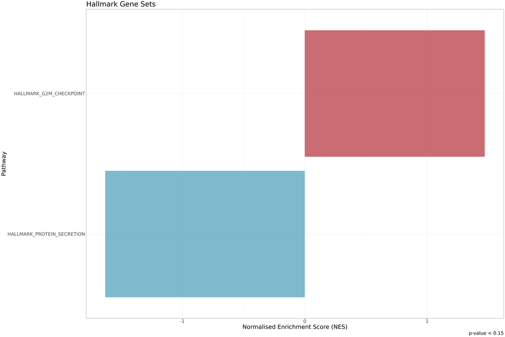

```r
hallmarks.res.tidy <- hallmarks.res %>%
  as_tibble() %>%
  arrange(desc(NES))

hallmarks.res.tidy %>%
  dplyr::select(-leadingEdge, -ES) %>%
  arrange(padj)

hallmark.sg.t <- hallmarks.res.tidy[,c(1,6)]
hallmark.sg.t <- as.data.frame(hallmark.sg.t)

#this small part is generic
thresh <- 0.15

#this one is no longer generic
data_to_plot <- hallmarks.res.tidy %>% filter(padj < thresh)

statvec <- c()
for (i in 1:nrow(data_to_plot)){
  if (data_to_plot[i,6] > 0){
    status <- "Upregulated"
  }
 else {
   status <- "Downregulated"
 }
statvec <- c(statvec, status)
}

data_to_plot$Status <- statvec

##-----HALMARK-----
gsea_plot_hall <- ggplot(data_to_plot, aes(reorder(pathway, NES), NES)) +
  geom_col(aes(fill= Status), alpha=0.75) + scale_fill_manual(values = c("#53A2BE","#BA3B46"), name = "Regulation Status", labels = c("Downregulated", "Upregulated"), breaks = c("Downregulated", "Upregulated")) +
  coord_flip() +
  labs(x="Pathway", y="Normalised Enrichment Score (NES)",
       title= "Hallmark Gene Sets",
       caption = paste0("p-value < ", thresh)) + theme(plot.title = element_text(hjust = 1)) +
  theme_bw() + theme(text=element_text(family = "Quicksand")) + theme(legend.position = "none")

gsea_plot_hall+
  theme(text=element_text(size=25,  family="Arial MS"))
```

NO SIGNIFICANT PATHWAYS!